# Machine Learning Engineer Nanodegree

## Project: Lending Club *Investor ML*

## Overview

LendingClub is an online financial community that brings together creditworthy borrowers and savvy investors so that both can benefit financially. They replace the high cost and complexity of bank lending with a faster, smarter way to borrow and invest. Since 2007, LendingClub has been bringing borrowers and investors together, transforming the way people access credit. Over the last 10 years, LendingClub helped millions of people take control of their debt, grow their small businesses, and invest for the future.

LendingClub balances different investors on its platform. The mechanics of the platform allow LendingClub to meet the objectives of many different types of investors, including retail investors. Here’s how it works. Once loans are approved to the LendingClub platform, they are randomly allocated at a grade and term level either to a program designed for retail investors purchasing interests in fractions of loans (e.g. LendingClub Notes) or to a program intended for institutional investors. This helps ensure that investors have access to comparable quality loans no matter which type of investor they are. LendingClub goal is to meet incoming investor demand for interests in fractional loans as much as possible.

The design of LendingClub platform emphasizes how important retail investors are to LendingClub. For LendingClub retail investors are key component of our diverse marketplace strategy. Retail investors are—and will always be—the heart of the LendingClub marketplace. This project “Investor ML” tool specifically built keeping retail investors in mind. Investor ML aims to predict probability risk of charged off and not fully paid, called “Risk Rate %”. LendingClub can provide “Risk Rate %” predictions from Investor ML for each approved loan as an additional indicator for investors to make investment decisions. Retail investors use loan information, applicant information like fico score, loan grade etc. and decide to invest in fractional loans. Additional statistic “Risk Rate %” learned from historical loans may also act as additional information and help retail investors to diversify their investment.

The datasets are provided by LendingClub, we will use lending data from 2007-2011 and be trying to classify and predict whether or not the borrower paid back their loan in full. Data is available to download [here](https://www.lendingclub.com/info/download-data.action).

## Exploring the Data

Lets load necessary Python libraries and load the Lendingclub data downloaded.

```python
# Import libraries necessary for this project
import numpy as np
import pandas as pd
from time import time
from IPython.display import display # Allows the use of display() for DataFrames
import warnings
warnings.filterwarnings("ignore")

# Import supplementary visualization code visuals.py
import visuals as vs

# Pretty display for notebooks
import matplotlib.pyplot as plt
import seaborn as sns
%matplotlib inline
color = sns.color_palette()


# Load the Census dataset
loans = pd.read_csv("LoanStats3a_securev1_2007_2011.csv", encoding='utf-8')

# Success - Display the first record
print ("Loans dataset has {} data points with {} variables each.".format(*loans.shape))
print('lending club data 2007 to 2011 {}: {}'.format(loans.shape, ', '.join(loans.columns)))
loans.head(n=4)
```

```
Loans dataset has 42542 data points with 151 variables each.
lending club data 2007 to 2011 (42542, 151): id, member_id, loan_amnt, funded_amnt, funded_amnt_inv, term, int_rate, installment, grade, sub_grade, emp_title, emp_length, home_ownership, annual_inc, verification_status, issue_d, loan_status, pymnt_plan, url, desc, purpose, title, zip_code, addr_stat…
```

|  | id | member_id | loan_amnt | funded_amnt | funded_amnt_inv | term | int_rate | installment | grade | sub_grade | ... | hardship_payoff_balance_amount | hardship_last_payment_amount | disbursement_method | debt_settlement_flag | debt_settlement_flag_date | settlement_status | settlement_date | settlement_amount | settlement_percentage | settlement_term |
| --- | --- | --- | --- | --- | --- | --- | --- | --- | --- | --- | --- | --- | --- | --- | --- | --- | --- | --- | --- | --- | --- |
| 0 | 1077501 | NaN | 5000.0 | 5000.0 | 4975.0 | 36 months | 10.65% | 162.87 | B | B2 | ... | NaN | NaN | Cash | N | NaN | NaN | NaN | NaN | NaN | NaN |
| 1 | 1077430 | NaN | 2500.0 | 2500.0 | 2500.0 | 60 months | 15.27% | 59.83 | C | C4 | ... | NaN | NaN | Cash | N | NaN | NaN | NaN | NaN | NaN | NaN |
| 2 | 1077175 | NaN | 2400.0 | 2400.0 | 2400.0 | 36 months | 15.96% | 84.33 | C | C5 | ... | NaN | NaN | Cash | N | NaN | NaN | NaN | NaN | NaN | NaN |
| 3 | 1076863 | NaN | 10000.0 | 10000.0 | 10000.0 | 36 months | 13.49% | 339.31 | C | C1 | ... | NaN | NaN | Cash | N | NaN | NaN | NaN | NaN | NaN | NaN |

4 rows × 151 columns

```python
loans.describe()
```

|  | member_id | loan_amnt | funded_amnt | funded_amnt_inv | installment | annual_inc | dti | delinq_2yrs | fico_range_low | fico_range_high | ... | payment_plan_start_date | hardship_length | hardship_dpd | hardship_loan_status | orig_projected_additional_accrued_interest | hardship_payoff_balance_amount | hardship_last_payment_amount | settlement_amount | settlement_percentage | settlement_term |
| --- | --- | --- | --- | --- | --- | --- | --- | --- | --- | --- | --- | --- | --- | --- | --- | --- | --- | --- | --- | --- | --- |
| count | 0.0 | 42535.000000 | 42535.000000 | 42535.000000 | 42535.000000 | 4.253100e+04 | 42535.000000 | 42506.000000 | 42535.000000 | 42535.000000 | ... | 0.0 | 0.0 | 0.0 | 0.0 | 0.0 | 0.0 | 0.0 | 156.000000 | 156.000000 | 156.000000 |
| mean | NaN | 11089.722581 | 10821.585753 | 10139.830603 | 322.623063 | 6.913656e+04 | 13.373043 | 0.152449 | 713.052545 | 717.052545 | ... | NaN | NaN | NaN | NaN | NaN | NaN | NaN | 4259.603077 | 49.935385 | 0.942308 |
| std | NaN | 7410.938391 | 7146.914675 | 7131.686447 | 208.927216 | 6.409635e+04 | 6.726315 | 0.512406 | 36.188439 | 36.188439 | ... | NaN | NaN | NaN | NaN | NaN | NaN | NaN | 3147.115163 | 15.707054 | 3.445877 |
| min | NaN | 500.000000 | 500.000000 | 0.000000 | 15.670000 | 1.896000e+03 | 0.000000 | 0.000000 | 610.000000 | 614.000000 | ... | NaN | NaN | NaN | NaN | NaN | NaN | NaN | 193.290000 | 10.690000 | 0.000000 |
| 25% | NaN | 5200.000000 | 5000.000000 | 4950.000000 | 165.520000 | 4.000000e+04 | 8.200000 | 0.000000 | 685.000000 | 689.000000 | ... | NaN | NaN | NaN | NaN | NaN | NaN | NaN | 1800.000000 | 40.000000 | 0.000000 |
| 50% | NaN | 9700.000000 | 9600.000000 | 8500.000000 | 277.690000 | 5.900000e+04 | 13.470000 | 0.000000 | 710.000000 | 714.000000 | ... | NaN | NaN | NaN | NaN | NaN | NaN | NaN | 3481.850000 | 49.980000 | 0.000000 |
| 75% | NaN | 15000.000000 | 15000.000000 | 14000.000000 | 428.180000 | 8.250000e+04 | 18.680000 | 0.000000 | 740.000000 | 744.000000 | ... | NaN | NaN | NaN | NaN | NaN | NaN | NaN | 5701.100000 | 60.700000 | 0.000000 |
| max | NaN | 35000.000000 | 35000.000000 | 35000.000000 | 1305.190000 | 6.000000e+06 | 29.990000 | 13.000000 | 825.000000 | 829.000000 | ... | NaN | NaN | NaN | NaN | NaN | NaN | NaN | 14798.200000 | 92.740000 | 24.000000 |

8 rows × 120 columns

## Data dictionary

**Definition list**

- **id**: A unique LC assigned ID for the loan listing.
- **loan_amnt**: The listed amount of the loan applied for by the borrower. If at some point in time, the credit department reduces the loan am"ount, then it will be reflected in this value.
- **funded_amnt**: The total amount committed to that loan at that point in time.
- **funded_amnt_inv**: The total amount committed by investors for that loan at that point in time.
- **term**: The number of payments on the loan. Values are in months and can be either 36 or 60.
- **int_rate**: Interest Rate on the loan
- **installment**: The monthly payment owed by the borrower if the loan originates.
- **grade**: LC assigned loan grade
- **sub_grade**: LC assigned loan subgrade
- **emp_title**: The job title supplied by the Borrower when applying for the loan.
- **emp_length**: Employment length in years. Possible values are between 0 and 10 where 0 means less than one year and 10 means ten or more years.
- **home_ownership**: The home ownership status provided by the borrower during registration or obtained from the credit report. Our values are: RENT, OWN, MORTGAGE, OTHER.
- **annual_inc**: The self-reported annual income provided by the borrower during registration.
- **verification_status**: Indicates if income was verified by LC, not verified, or if the income source was verified.
- **issue_d**: The month which the loan was funded.
- **loan_status**: Current status of the loan.
- **pymnt_plan**: Indicates if a payment plan has been put in place for the loan.
- **url**: URL for the LC page with listing data.
- **desc**: Loan description provided by the borrower.
- **purpose**: A category provided by the borrower for the loan request.
- **title**: The loan title provided by the borrower.
- **zip_code**: The first 3 numbers of the zip code provided by the borrower in the loan application.
- **addr_state**: The state provided by the borrower in the loan application.
- **dti**: A ratio calculated using the borrower’s total monthly debt payments on the total debt obligations, excluding mortgage and the requested LC loan, divided by the borrower’s self-reported monthly income.
- **delinq_2yrs**: The number of 30+ days past-due incidences of delinquency in the borrower's credit file for the past 2 years.
- **earliest_cr_line**: The month the borrower's earliest reported credit line was opened.
- **fico_range_low**: The lower boundary range the borrower’s FICO at loan origination belongs to.
- **fico_range_high**: The upper boundary range the borrower’s FICO at loan origination belongs to.
- **inq_last_6mths**: The number of inquiries in past 6 months (excluding auto and mortgage inquiries).
- **mths_since_last_delinq**: The number of months since the borrower's last delinquency.
- **mths_since_last_record**: The number of months since the last public record.
- **open_acc**: The number of open credit lines in the borrower's credit file.
- **pub_rec**: Number of derogatory public records.
- **revol_bal**: Total credit revolving balance.
- **revol_util**: Revolving line utilization rate, or the amount of credit the borrower is using relative to all available revolving credit.
- **total_acc**: The total number of credit lines currently in the borrower's credit file.
- **initial_list_status**: The initial listing status of the loan. Possible values are – W, F.
- **out_prncp**: Remaining outstanding principal for total amount funded.
- **out_prncp_inv**: Remaining outstanding principal for portion of total amount funded by investors.
- **total_pymnt**: Payments received to date for total amount funded.
- **total_pymnt_inv**: Payments received to date for portion of total amount funded by investors.
- **total_rec_prncp**: Principal received to date.
- **total_rec_int**: Interest received to date.
- **total_rec_late_fee**: Late fees received to date.
- **recoveries**: post charge off gross recovery.
- **collection_recovery_fee**: post charge off collection fee.
- **last_pymnt_d**: Last month payment was received.
- **last_pymnt_amnt**: Last total payment amount received.
- **next_pymnt_d**: Next scheduled payment date.
- **last_credit_pull_d**: The most recent month LC pulled credit for this loan.
- **last_fico_range_high**: The upper boundary range the borrower’s last FICO pulled belongs to.
- **last_fico_range_low**: The lower boundary range the borrower’s last FICO pulled belongs to.
- **collections_12_mths_ex_med**: Number of collections in 12 months excluding medical collections.
- **policy_code**: publicly available policy_code=1, new products not publicly available policy_code=2.
- **application_type**: Indicates whether the loan is an individual application or a joint application with two co-borrowers.
- **acc_now_delinq**: The number of accounts on which the borrower is now delinquent.
- **chargeoff_within_12_mths**: Number of charge-offs within 12 months.
- **delinq_amnt**: The past-due amount owed for the accounts on which the borrower is now delinquent.
- **pub_rec_bankruptcies**: Number of public record bankruptcies.
- **tax_liens**: Number of tax liens.
- **hardship_flag**: Flags whether or not the borrower is on a hardship plan.
- **disbursement_method**: The method by which the borrower receives their loan. Possible values are: CASH, DIRECT_PAY.
- **debt_settlement_flag**: Flags whether or not the borrower, who has charged-off, is working with a debt-settlement company.
- **debt_settlement_flag_date**: The most recent date that the Debt_Settlement_Flag has been set.
- **settlement_status**: The status of the borrower’s settlement plan. Possible values are: COMPLETE, ACTIVE, BROKEN, CANCELLED, DENIED, DRAFT.
- **settlement_date**: The date that the borrower agrees to the settlement plan.
- **settlement_amount**: The loan amount that the borrower has agreed to settle for.
- **settlement_percentage**: The settlement amount as a percentage of the payoff balance amount on the loan.
- **settlement_term**: The number of months that the borrower will be on the settlement plan.

### Identify NaNs

Lets analyze the Nans values to first focus on the data that has decent population to analyze the data. As we see NaN values, lets see how many NA values are present.

```python
# Success
print ("Before removing NA")
print "Dataset has {} data points with {} variables each.".format(*loans.shape)
print(loans.isnull().sum())
```

```
Before removing NA
Dataset has 42542 data points with 151 variables each.
id                                                4
member_id                                     42542
loan_amnt                                         7
funded_amnt                                       7
funded_amnt_inv                                   7
term                                              7
int_rate                                          7
installment                                       7
grade                                             7
sub_grade                                         7
emp_title                                      2631
emp_length                                        7
home_ownership                                    7
annual_inc                                       11
verification_status                               7
issue_d                                           7
loan_status                                       7
pymnt_plan                                        7
url                                               7
desc                                          13299
purpose                                           7
title                                            19
zip_code                                          7
addr_state                                        7
dti                                               7
delinq_2yrs                                      36
earliest_cr_line                                 36
fico_range_low                                    7
fico_range_high                                   7
inq_last_6mths                                   36
                                              ...
sec_app_open_acc                              42542
sec_app_revol_util                            42542
sec_app_open_act_il                           42542
sec_app_num_rev_accts                         42542
sec_app_chargeoff_within_12_mths              42542
sec_app_collections_12_mths_ex_med            42542
sec_app_mths_since_last_major_derog           42542
```

[output cut: 9 more lines]

```
hardship_length                               42542
hardship_dpd                                  42542
hardship_loan_status                          42542
orig_projected_additional_accrued_interest    42542
hardship_payoff_balance_amount                42542
hardship_last_payment_amount                  42542
disbursement_method                               7
debt_settlement_flag                              7
debt_settlement_flag_date                     42386
settlement_status                             42386
settlement_date                               42386
settlement_amount                             42386
settlement_percentage                         42386
settlement_term                               42386
Length: 151, dtype: int64
```

```python
# drop a column if all values are NaN
loans = loans.dropna(thresh=0.4*len(loans),  axis = 1)
print "Loans dataset has {} data points with {} variables each.".format(*loans.shape)
#loans.info()
```

```
Loans dataset has 42542 data points with 60 variables each.
```

Now we can analyse all the data in 60 columns which have at least 40% records or more of data populated for each columns.

**Assumption**

For investors, only information about loan applicant is available, following 41 features, that is assumed to be available for investors.

Available features of loan applicant

**Identifiers, not needed as features**

- **id**: A unique LC assigned ID for the loan listing.
- **url**: URL for the LC page with listing data.

**Other features to analyze**

- **loan_amnt**: The listed amount of the loan applied for by the borrower. If at some point in time, the credit department reduces the loan am"ount, then it will be reflected in this value.
- **term**: The number of payments on the loan. Values are in months and can be either 36 or 60.
- **int_rate**: Interest Rate on the loan.
- **grade**: LC assigned loan grade.
- **sub_grade**: LC assigned loan subgrade.
- **emp_title**: The job title supplied by the Borrower when applying for the loan.
- **emp_length**: Employment length in years. Possible values are between 0 and 10 where 0 means less than one year and 10 means ten or more years.
- **home_ownership**: The home ownership status provided by the borrower during registration or obtained from the credit report. Our values are: RENT, OWN, MORTGAGE, OTHER.
- **annual_inc**: The self-reported annual income provided by the borrower during registration.
- **verification_status**: Indicates if income was verified by LC, not verified, or if the income source was verified.
- **loan_status**: Current status of the loan.
- **desc**: Loan description provided by the borrower.
- **purpose**: A category provided by the borrower for the loan request.
- **title**: The loan title provided by the borrower.
- **zip_code**: The first 3 numbers of the zip code provided by the borrower in the loan application.
- **addr_state**: The state provided by the borrower in the loan application.
- **dti**: A ratio calculated using the borrower’s total monthly debt payments on the total debt obligations, excluding mortgage and the requested LC loan, divided by the borrower’s self-reported monthly income.
- **delinq_2yrs**: The number of 30+ days past-due incidences of delinquency in the borrower's credit file for the past 2 years.
- **earliest_cr_line**: The month the borrower's earliest reported credit line was opened.
- **fico_range_low**: The lower boundary range the borrower’s FICO at loan origination belongs to.
- **fico_range_high**: The upper boundary range the borrower’s FICO at loan origination belongs to.
- **inq_last_6mths**: The number of inquiries in past 6 months (excluding auto and mortgage inquiries).
- **mths_since_last_delinq**: The number of months since the borrower's last delinquency.
- **mths_since_last_record**: The number of months since the last public record.
- **open_acc**: The number of open credit lines in the borrower's credit file.
- **pub_rec**: Number of derogatory public records.
- **revol_bal**: Total credit revolving balance.
- **revol_util**: Revolving line utilization rate, or the amount of credit the borrower is using relative to all available revolving credit.
- **total_acc**: The total number of credit lines currently in the borrower's credit file.
- **initial_list_status**: The initial listing status of the loan. Possible values are – W, F.
- **out_prncp**: Remaining outstanding principal for total amount funded.
- **out_prncp_inv**: Remaining outstanding principal for portion of total amount funded by investors.
- **last_credit_pull_d**: The most recent month LC pulled credit for this loan.
- **last_fico_range_high**: The upper boundary range the borrower’s last FICO pulled belongs to.
- **last_fico_range_low**: The lower boundary range the borrower’s last FICO pulled belongs to.
- **collections_12_mths_ex_med**: Number of collections in 12 months excluding medical collections.
- **policy_code**: publicly available policy_code=1, new products not publicly available policy_code=2.
- **application_type**: Indicates whether the loan is an individual application or a joint application with two co-borrowers.
- **acc_now_delinq**: The number of accounts on which the borrower is now delinquent.
- **delinq_amnt**: The past-due amount owed for the accounts on which the borrower is now delinquent.
- **pub_rec_bankruptcies**: Number of public record bankruptcies.
- **tax_liens**: Number of tax liens.
- **hardship_flag**: Flags whether or not the borrower is on a hardship plan.

```python
identifiers = ['id', 'url']
investor_features = loans[['loan_amnt','term','int_rate','grade','sub_grade','emp_title','emp_length',\
               'home_ownership','annual_inc','verification_status','loan_status',\
               'desc','purpose','title','zip_code','addr_state','dti','delinq_2yrs',\
               'earliest_cr_line','fico_range_low','fico_range_high','inq_last_6mths',\
               'open_acc','pub_rec','revol_bal','revol_util','total_acc',\
               'initial_list_status','out_prncp','out_prncp_inv','last_credit_pull_d','last_fico_range_high',\
               'last_fico_range_low','collections_12_mths_ex_med','policy_code','application_type','acc_now_delinq',\
               'delinq_amnt','pub_rec_bankruptcies','tax_liens','hardship_flag']]
#loans.info()
investor_features.shape
```

```
(42542, 41)
```

Found interesting tool pandas_profiling, will use that to profile and learn more about data.

Overview

Dataset info

| Number of variables | 41 |
| --- | --- |
| Number of observations | 42542 |
| Total Missing (%) | 0.0% |
| Total size in memory | 13.3 MiB |
| Average record size in memory | 328.0 B |

Variables types

| Numeric | 16 |
| --- | --- |
| Categorical | 20 |
| Boolean | 4 |
| Date | 0 |
| Text (Unique) | 0 |
| Rejected | 1 |
| Unsupported | 0 |

Warnings

- `acc_now_delinq` is highly skewed (γ1 = 103.07) Skewed

- `acc_now_delinq` has 36 / 100.0% missing values Missing

- `addr_state` has 7 / 100.0% missing values Missing

- `addr_state` has a high cardinality: 51 distinct values Warning

- `annual_inc` is highly skewed (γ1 = 29.035) Skewed

- `annual_inc` has 11 / 100.0% missing values Missing

- `application_type` has 7 / 100.0% missing values Missing

- `collections_12_mths_ex_med` has 152 / 100.0% missing values Missing

- `delinq_2yrs` has 36 / 100.0% missing values Missing

- `delinq_amnt` is highly skewed (γ1 = 206.16) Skewed

- `delinq_amnt` has 36 / 100.0% missing values Missing

- `desc` has 13299 / 100.0% missing values Missing

- `desc` has a high cardinality: 28965 distinct values Warning

- `dti` has 7 / 100.0% missing values Missing

- `earliest_cr_line` has 36 / 100.0% missing values Missing

- `earliest_cr_line` has a high cardinality: 531 distinct values Warning

- `emp_length` has 7 / 100.0% missing values Missing

- `emp_title` has 2631 / 100.0% missing values Missing

- `emp_title` has a high cardinality: 30660 distinct values Warning

- `fico_range_high` is highly correlated with `fico_range_low` (ρ = 1) Rejected

- `fico_range_low` has 7 / 100.0% missing values Missing

- `grade` has 7 / 100.0% missing values Missing

- `hardship_flag` has 7 / 100.0% missing values Missing

- `home_ownership` has 7 / 100.0% missing values Missing

- `initial_list_status` has 7 / 100.0% missing values Missing

- `inq_last_6mths` has 36 / 100.0% missing values Missing

- `int_rate` has 7 / 100.0% missing values Missing

- `int_rate` has a high cardinality: 395 distinct values Warning

- `last_credit_pull_d` has 11 / 100.0% missing values Missing

- `last_credit_pull_d` has a high cardinality: 128 distinct values Warning

- `last_fico_range_high` has 7 / 100.0% missing values Missing

- `last_fico_range_low` has 7 / 100.0% missing values Missing

- `loan_amnt` has 7 / 100.0% missing values Missing

- `loan_status` has 7 / 100.0% missing values Missing

- `open_acc` has 36 / 100.0% missing values Missing

- `out_prncp` has 7 / 100.0% missing values Missing

- `out_prncp_inv` has 7 / 100.0% missing values Missing

- `policy_code` has 7 / 100.0% missing values Missing

- `pub_rec` has 36 / 100.0% missing values Missing

- `pub_rec_bankruptcies` has 1372 / 100.0% missing values Missing

- `purpose` has 7 / 100.0% missing values Missing

- `revol_bal` has 7 / 100.0% missing values Missing

- `revol_util` has 97 / 100.0% missing values Missing

- `revol_util` has a high cardinality: 1120 distinct values Warning

- `sub_grade` has 7 / 100.0% missing values Missing

- `tax_liens` is highly skewed (γ1 = 205.99) Skewed

- `tax_liens` has 112 / 100.0% missing values Missing

- `term` has 7 / 100.0% missing values Missing

- `title` has 19 / 100.0% missing values Missing

- `title` has a high cardinality: 21258 distinct values Warning

- `total_acc` has 36 / 100.0% missing values Missing

- `verification_status` has 7 / 100.0% missing values Missing

- `zip_code` has 7 / 100.0% missing values Missing

- `zip_code` has a high cardinality: 838 distinct values Warning

- Dataset has 6 duplicate rows Warning

Variables

acc_now_delinq  
Numeric

| Distinct count | 3 |
| --- | --- |
| Unique (%) | 0.0% |
| Missing (%) | 100.0% |
| Missing (n) | 36 |
| Infinite (%) | 0.0% |
| Infinite (n) | 0 |

| Mean | 9.4104e-05 |
| --- | --- |
| Minimum | 0 |
| Maximum | 1 |
| Zeros (%) | 0.0% |

Toggle details

**Statistics**

Quantile statistics

| Minimum | 0 |
| --- | --- |
| 5-th percentile | 0 |
| Q1 | 0 |
| Median | 0 |
| Q3 | 0 |
| 95-th percentile | 0 |
| Maximum | 1 |
| Range | 1 |
| Interquartile range | 0 |

Descriptive statistics

| Standard deviation | 0.0097004 |
| --- | --- |
| Coef of variation | 103.08 |
| Kurtosis | 10623 |
| Mean | 9.4104e-05 |
| MAD | 0.00018819 |
| Skewness | 103.07 |
| Sum | 4 |
| Variance | 9.4098e-05 |
| Memory size | 332.4 KiB |

**Histogram**

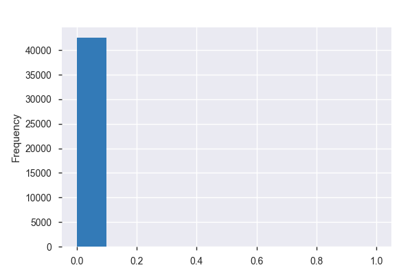

**Common Values**

| Value | Count | Frequency (%) |  |
| --- | --- | --- | --- |
| 0.0 | 42502 | 0.0% |  |
| 1.0 | 4 | 0.0% |  |
| (Missing) | 36 | 0.0% |  |

**Extreme Values**

Minimum 5 values

| Value | Count | Frequency (%) |  |
| --- | --- | --- | --- |
| 0.0 | 42502 | 0.0% |  |
| 1.0 | 4 | 0.0% |  |

Maximum 5 values

| Value | Count | Frequency (%) |  |
| --- | --- | --- | --- |
| 0.0 | 42502 | 0.0% |  |
| 1.0 | 4 | 0.0% |  |

addr_state  
Categorical

| Distinct count | 51 |
| --- | --- |
| Unique (%) | 0.0% |
| Missing (%) | 100.0% |
| Missing (n) | 7 |

| CA | 7429 |
| --- | --- |
| NY | 4065 |
| FL | 3104 |
| Other values (47) | 27937 |

Toggle details

| Value | Count | Frequency (%) |  |
| --- | --- | --- | --- |
| CA | 7429 | 0.0% |  |
| NY | 4065 | 0.0% |  |
| FL | 3104 | 0.0% |  |
| TX | 2915 | 0.0% |  |
| NJ | 1988 | 0.0% |  |
| IL | 1672 | 0.0% |  |
| PA | 1651 | 0.0% |  |
| GA | 1503 | 0.0% |  |
| VA | 1487 | 0.0% |  |
| MA | 1438 | 0.0% |  |
| Other values (40) | 15283 | 0.0% |  |

annual_inc  
Numeric

| Distinct count | 5598 |
| --- | --- |
| Unique (%) | 0.0% |
| Missing (%) | 100.0% |
| Missing (n) | 11 |
| Infinite (%) | 0.0% |
| Infinite (n) | 0 |

| Mean | 69137 |
| --- | --- |
| Minimum | 1896 |
| Maximum | 6000000 |
| Zeros (%) | 0.0% |

Toggle details

**Statistics**

Quantile statistics

| Minimum | 1896 |
| --- | --- |
| 5-th percentile | 24000 |
| Q1 | 40000 |
| Median | 59000 |
| Q3 | 82500 |
| 95-th percentile | 144000 |
| Maximum | 6000000 |
| Range | 5998100 |
| Interquartile range | 42500 |

Descriptive statistics

| Standard deviation | 64096 |
| --- | --- |
| Coef of variation | 0.9271 |
| Kurtosis | 2117.3 |
| Mean | 69137 |
| MAD | 30995 |
| Skewness | 29.035 |
| Sum | 2940400000 |
| Variance | 4108300000 |
| Memory size | 332.4 KiB |

**Histogram**

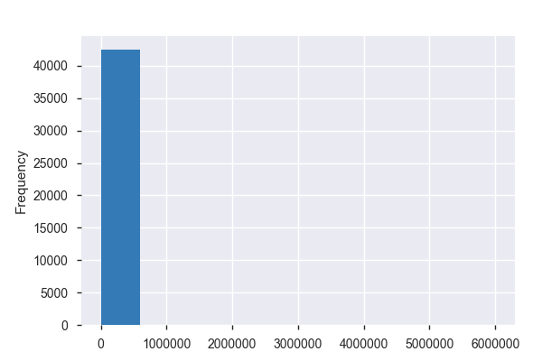

**Common Values**

| Value | Count | Frequency (%) |  |
| --- | --- | --- | --- |
| 60000.0 | 1591 | 0.0% |  |
| 50000.0 | 1119 | 0.0% |  |
| 40000.0 | 935 | 0.0% |  |
| 45000.0 | 898 | 0.0% |  |
| 30000.0 | 884 | 0.0% |  |
| 75000.0 | 865 | 0.0% |  |
| 65000.0 | 840 | 0.0% |  |
| 70000.0 | 790 | 0.0% |  |
| 48000.0 | 766 | 0.0% |  |
| 80000.0 | 718 | 0.0% |  |
| Other values (5587) | 33125 | 0.0% |  |

**Extreme Values**

Minimum 5 values

| Value | Count | Frequency (%) |  |
| --- | --- | --- | --- |
| 1896.0 | 1 | 0.0% |  |
| 2000.0 | 1 | 0.0% |  |
| 3300.0 | 1 | 0.0% |  |
| 3500.0 | 1 | 0.0% |  |
| 3600.0 | 1 | 0.0% |  |

Maximum 5 values

| Value | Count | Frequency (%) |  |
| --- | --- | --- | --- |
| 1782000.0 | 1 | 0.0% |  |
| 1900000.0 | 1 | 0.0% |  |
| 2039784.0 | 1 | 0.0% |  |
| 3900000.0 | 1 | 0.0% |  |
| 6000000.0 | 1 | 0.0% |  |

application_type  
Categorical

| Distinct count | 2 |
| --- | --- |
| Unique (%) | 0.0% |
| Missing (%) | 100.0% |
| Missing (n) | 7 |

| Individual | 42535 |
| --- | --- |
| (Missing) | 7 |

Toggle details

| Value | Count | Frequency (%) |  |
| --- | --- | --- | --- |
| Individual | 42535 | 0.0% |  |
| (Missing) | 7 | 0.0% |  |

collections_12_mths_ex_med  
Boolean

| Distinct count | 2 |
| --- | --- |
| Unique (%) | 0.0% |
| Missing (%) | 100.0% |
| Missing (n) | 152 |

| Mean | 0 |
| --- | --- |

| 0.0 | 42390 |
| --- | --- |
| (Missing) | 152 |

Toggle details

| Value | Count | Frequency (%) |  |
| --- | --- | --- | --- |
| 0.0 | 42390 | 0.0% |  |
| (Missing) | 152 | 0.0% |  |

delinq_2yrs  
Numeric

| Distinct count | 13 |
| --- | --- |
| Unique (%) | 0.0% |
| Missing (%) | 100.0% |
| Missing (n) | 36 |
| Infinite (%) | 0.0% |
| Infinite (n) | 0 |

| Mean | 0.15245 |
| --- | --- |
| Minimum | 0 |
| Maximum | 13 |
| Zeros (%) | 0.0% |

Toggle details

**Statistics**

Quantile statistics

| Minimum | 0 |
| --- | --- |
| 5-th percentile | 0 |
| Q1 | 0 |
| Median | 0 |
| Q3 | 0 |
| 95-th percentile | 1 |
| Maximum | 13 |
| Range | 13 |
| Interquartile range | 0 |

Descriptive statistics

| Standard deviation | 0.51241 |
| --- | --- |
| Coef of variation | 3.3612 |
| Kurtosis | 51.073 |
| Mean | 0.15245 |
| MAD | 0.27093 |
| Skewness | 5.4334 |
| Sum | 6480 |
| Variance | 0.26256 |
| Memory size | 332.4 KiB |

**Histogram**

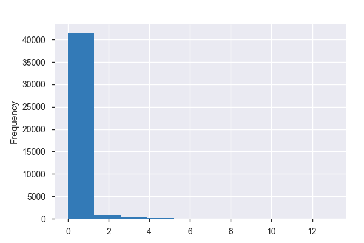

**Common Values**

| Value | Count | Frequency (%) |  |
| --- | --- | --- | --- |
| 0.0 | 37771 | 0.0% |  |
| 1.0 | 3595 | 0.0% |  |
| 2.0 | 771 | 0.0% |  |
| 3.0 | 244 | 0.0% |  |
| 4.0 | 72 | 0.0% |  |
| 5.0 | 27 | 0.0% |  |
| 6.0 | 13 | 0.0% |  |
| 7.0 | 6 | 0.0% |  |
| 8.0 | 3 | 0.0% |  |
| 11.0 | 2 | 0.0% |  |
| Other values (2) | 2 | 0.0% |  |
| (Missing) | 36 | 0.0% |  |

**Extreme Values**

Minimum 5 values

| Value | Count | Frequency (%) |  |
| --- | --- | --- | --- |
| 0.0 | 37771 | 0.0% |  |
| 1.0 | 3595 | 0.0% |  |
| 2.0 | 771 | 0.0% |  |
| 3.0 | 244 | 0.0% |  |
| 4.0 | 72 | 0.0% |  |

Maximum 5 values

| Value | Count | Frequency (%) |  |
| --- | --- | --- | --- |
| 7.0 | 6 | 0.0% |  |
| 8.0 | 3 | 0.0% |  |
| 9.0 | 1 | 0.0% |  |
| 11.0 | 2 | 0.0% |  |
| 13.0 | 1 | 0.0% |  |

delinq_amnt  
Numeric

| Distinct count | 4 |
| --- | --- |
| Unique (%) | 0.0% |
| Missing (%) | 100.0% |
| Missing (n) | 36 |
| Infinite (%) | 0.0% |
| Infinite (n) | 0 |

| Mean | 0.14304 |
| --- | --- |
| Minimum | 0 |
| Maximum | 6053 |
| Zeros (%) | 0.0% |

Toggle details

**Statistics**

Quantile statistics

| Minimum | 0 |
| --- | --- |
| 5-th percentile | 0 |
| Q1 | 0 |
| Median | 0 |
| Q3 | 0 |
| 95-th percentile | 0 |
| Maximum | 6053 |
| Range | 6053 |
| Interquartile range | 0 |

Descriptive statistics

| Standard deviation | 29.36 |
| --- | --- |
| Coef of variation | 205.26 |
| Kurtosis | 42504 |
| Mean | 0.14304 |
| MAD | 0.28606 |
| Skewness | 206.16 |
| Sum | 6080 |
| Variance | 861.98 |
| Memory size | 332.4 KiB |

**Histogram**

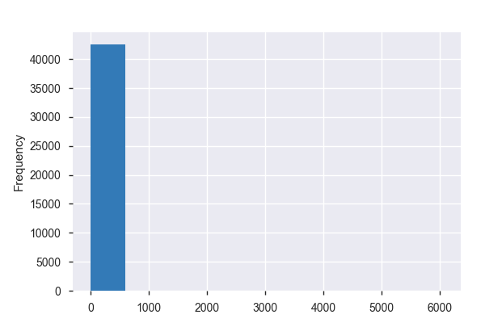

**Common Values**

| Value | Count | Frequency (%) |  |
| --- | --- | --- | --- |
| 0.0 | 42504 | 0.0% |  |
| 6053.0 | 1 | 0.0% |  |
| 27.0 | 1 | 0.0% |  |
| (Missing) | 36 | 0.0% |  |

**Extreme Values**

Minimum 5 values

| Value | Count | Frequency (%) |  |
| --- | --- | --- | --- |
| 0.0 | 42504 | 0.0% |  |
| 27.0 | 1 | 0.0% |  |
| 6053.0 | 1 | 0.0% |  |

Maximum 5 values

| Value | Count | Frequency (%) |  |
| --- | --- | --- | --- |
| 0.0 | 42504 | 0.0% |  |
| 27.0 | 1 | 0.0% |  |
| 6053.0 | 1 | 0.0% |  |

desc  
Categorical

| Distinct count | 28965 |
| --- | --- |
| Unique (%) | 0.0% |
| Missing (%) | 100.0% |
| Missing (n) | 13299 |

|  | 225 |
| --- | --- |
| Debt Consolidation | 11 |
| Camping Membership | 8 |
| Other values (28961) | 28999 |
| (Missing) | 13299 |

Toggle details

| Value | Count | Frequency (%) |  |
| --- | --- | --- | --- |
|  | 225 | 0.0% |  |
| Debt Consolidation | 11 | 0.0% |  |
| Camping Membership | 8 | 0.0% |  |
| refinancing | 5 | 0.0% |  |
| Personal Loan | 3 | 0.0% |  |
| personal loan | 3 | 0.0% |  |
| credit card consolidation | 3 | 0.0% |  |
| credit card debt consolidation | 3 | 0.0% |  |
| consolidate debt | 3 | 0.0% |  |
| debt consolidation | 3 | 0.0% |  |
| Other values (28954) | 28976 | 0.0% |  |
| (Missing) | 13299 | 0.0% |  |

dti  
Numeric

| Distinct count | 2895 |
| --- | --- |
| Unique (%) | 0.0% |
| Missing (%) | 100.0% |
| Missing (n) | 7 |
| Infinite (%) | 0.0% |
| Infinite (n) | 0 |

| Mean | 13.373 |
| --- | --- |
| Minimum | 0 |
| Maximum | 29.99 |
| Zeros (%) | 0.0% |

Toggle details

**Statistics**

Quantile statistics

| Minimum | 0 |
| --- | --- |
| 5-th percentile | 2.1 |
| Q1 | 8.2 |
| Median | 13.47 |
| Q3 | 18.68 |
| 95-th percentile | 23.92 |
| Maximum | 29.99 |
| Range | 29.99 |
| Interquartile range | 10.48 |

Descriptive statistics

| Standard deviation | 6.7263 |
| --- | --- |
| Coef of variation | 0.50298 |
| Kurtosis | -0.85174 |
| Mean | 13.373 |
| MAD | 5.6401 |
| Skewness | -0.029922 |
| Sum | 568820 |
| Variance | 45.243 |
| Memory size | 332.4 KiB |

**Histogram**

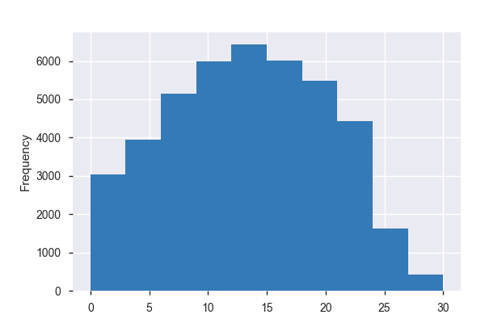

**Common Values**

| Value | Count | Frequency (%) |  |
| --- | --- | --- | --- |
| 0.0 | 206 | 0.0% |  |
| 12.0 | 54 | 0.0% |  |
| 10.0 | 46 | 0.0% |  |
| 18.0 | 46 | 0.0% |  |
| 19.2 | 45 | 0.0% |  |
| 13.2 | 43 | 0.0% |  |
| 16.8 | 41 | 0.0% |  |
| 13.5 | 41 | 0.0% |  |
| 12.48 | 40 | 0.0% |  |
| 15.0 | 38 | 0.0% |  |
| Other values (2884) | 41935 | 0.0% |  |

**Extreme Values**

Minimum 5 values

| Value | Count | Frequency (%) |  |
| --- | --- | --- | --- |
| 0.0 | 206 | 0.0% |  |
| 0.01 | 3 | 0.0% |  |
| 0.02 | 5 | 0.0% |  |
| 0.03 | 2 | 0.0% |  |
| 0.04 | 3 | 0.0% |  |

Maximum 5 values

| Value | Count | Frequency (%) |  |
| --- | --- | --- | --- |
| 29.92 | 2 | 0.0% |  |
| 29.93 | 3 | 0.0% |  |
| 29.95 | 2 | 0.0% |  |
| 29.96 | 1 | 0.0% |  |
| 29.99 | 1 | 0.0% |  |

earliest_cr_line  
Categorical

| Distinct count | 531 |
| --- | --- |
| Unique (%) | 0.0% |
| Missing (%) | 100.0% |
| Missing (n) | 36 |

| Oct-99 | 393 |
| --- | --- |
| Nov-98 | 390 |
| Oct-00 | 370 |
| Other values (527) | 41353 |

Toggle details

| Value | Count | Frequency (%) |  |
| --- | --- | --- | --- |
| Oct-99 | 393 | 0.0% |  |
| Nov-98 | 390 | 0.0% |  |
| Oct-00 | 370 | 0.0% |  |
| Dec-98 | 366 | 0.0% |  |
| Dec-97 | 348 | 0.0% |  |
| Nov-00 | 340 | 0.0% |  |
| Nov-99 | 337 | 0.0% |  |
| Oct-98 | 334 | 0.0% |  |
| Sep-00 | 325 | 0.0% |  |
| Nov-97 | 319 | 0.0% |  |
| Other values (520) | 38984 | 0.0% |  |

emp_length  
Categorical

| Distinct count | 13 |
| --- | --- |
| Unique (%) | 0.0% |
| Missing (%) | 100.0% |
| Missing (n) | 7 |

| 10+ years | 9369 |
| --- | --- |
| < 1 year | 5062 |
| 2 years | 4743 |
| Other values (9) | 23361 |

Toggle details

| Value | Count | Frequency (%) |  |
| --- | --- | --- | --- |
| 10+ years | 9369 | 0.0% |  |
| < 1 year | 5062 | 0.0% |  |
| 2 years | 4743 | 0.0% |  |
| 3 years | 4364 | 0.0% |  |
| 4 years | 3649 | 0.0% |  |
| 1 year | 3595 | 0.0% |  |
| 5 years | 3458 | 0.0% |  |
| 6 years | 2375 | 0.0% |  |
| 7 years | 1875 | 0.0% |  |
| 8 years | 1592 | 0.0% |  |
| Other values (2) | 2453 | 0.0% |  |

emp_title  
Categorical

| Distinct count | 30660 |
| --- | --- |
| Unique (%) | 0.0% |
| Missing (%) | 100.0% |
| Missing (n) | 2631 |

| US Army | 139 |
| --- | --- |
| Bank of America | 115 |
| IBM | 72 |
| Other values (30656) | 39585 |
| (Missing) | 2631 |

Toggle details

| Value | Count | Frequency (%) |  |
| --- | --- | --- | --- |
| US Army | 139 | 0.0% |  |
| Bank of America | 115 | 0.0% |  |
| IBM | 72 | 0.0% |  |
| Kaiser Permanente | 61 | 0.0% |  |
| AT&T | 61 | 0.0% |  |
| UPS | 58 | 0.0% |  |
| Wells Fargo | 57 | 0.0% |  |
| USAF | 56 | 0.0% |  |
| US Air Force | 55 | 0.0% |  |
| Self Employed | 49 | 0.0% |  |
| Other values (30649) | 39188 | 0.0% |  |
| (Missing) | 2631 | 0.0% |  |

fico_range_high  
Highly correlated

*This variable is highly correlated with `fico_range_low` and should be ignored for analysis*

| Correlation | 1 |
| --- | --- |

fico_range_low  
Numeric

| Distinct count | 45 |
| --- | --- |
| Unique (%) | 0.0% |
| Missing (%) | 100.0% |
| Missing (n) | 7 |
| Infinite (%) | 0.0% |
| Infinite (n) | 0 |

| Mean | 713.05 |
| --- | --- |
| Minimum | 610 |
| Maximum | 825 |
| Zeros (%) | 0.0% |

Toggle details

**Statistics**

Quantile statistics

| Minimum | 610 |
| --- | --- |
| 5-th percentile | 665 |
| Q1 | 685 |
| Median | 710 |
| Q3 | 740 |
| 95-th percentile | 780 |
| Maximum | 825 |
| Range | 215 |
| Interquartile range | 55 |

Descriptive statistics

| Standard deviation | 36.188 |
| --- | --- |
| Coef of variation | 0.050751 |
| Kurtosis | -0.49633 |
| Mean | 713.05 |
| MAD | 30.05 |
| Skewness | 0.46487 |
| Sum | 30330000 |
| Variance | 1309.6 |
| Memory size | 332.4 KiB |

**Histogram**

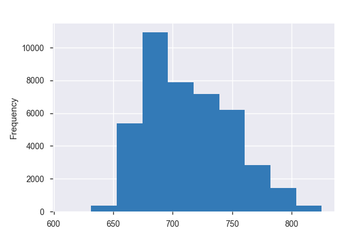

**Common Values**

| Value | Count | Frequency (%) |  |
| --- | --- | --- | --- |
| 685.0 | 2310 | 0.0% |  |
| 700.0 | 2267 | 0.0% |  |
| 680.0 | 2228 | 0.0% |  |
| 695.0 | 2202 | 0.0% |  |
| 690.0 | 2196 | 0.0% |  |
| 675.0 | 1994 | 0.0% |  |
| 705.0 | 1970 | 0.0% |  |
| 720.0 | 1949 | 0.0% |  |
| 715.0 | 1891 | 0.0% |  |
| 725.0 | 1891 | 0.0% |  |
| Other values (34) | 21637 | 0.0% |  |

**Extreme Values**

Minimum 5 values

| Value | Count | Frequency (%) |  |
| --- | --- | --- | --- |
| 610.0 | 2 | 0.0% |  |
| 615.0 | 1 | 0.0% |  |
| 620.0 | 1 | 0.0% |  |
| 625.0 | 2 | 0.0% |  |
| 630.0 | 6 | 0.0% |  |

Maximum 5 values

| Value | Count | Frequency (%) |  |
| --- | --- | --- | --- |
| 805.0 | 193 | 0.0% |  |
| 810.0 | 125 | 0.0% |  |
| 815.0 | 28 | 0.0% |  |
| 820.0 | 19 | 0.0% |  |
| 825.0 | 3 | 0.0% |  |

grade  
Categorical

| Distinct count | 8 |
| --- | --- |
| Unique (%) | 0.0% |
| Missing (%) | 100.0% |
| Missing (n) | 7 |

| B | 12389 |
| --- | --- |
| A | 10183 |
| C | 8740 |
| Other values (4) | 11223 |

Toggle details

| Value | Count | Frequency (%) |  |
| --- | --- | --- | --- |
| B | 12389 | 0.0% |  |
| A | 10183 | 0.0% |  |
| C | 8740 | 0.0% |  |
| D | 6016 | 0.0% |  |
| E | 3394 | 0.0% |  |
| F | 1301 | 0.0% |  |
| G | 512 | 0.0% |  |
| (Missing) | 7 | 0.0% |  |

hardship_flag  
Categorical

| Distinct count | 2 |
| --- | --- |
| Unique (%) | 0.0% |
| Missing (%) | 100.0% |
| Missing (n) | 7 |

| N | 42535 |
| --- | --- |
| (Missing) | 7 |

Toggle details

| Value | Count | Frequency (%) |  |
| --- | --- | --- | --- |
| N | 42535 | 0.0% |  |
| (Missing) | 7 | 0.0% |  |

home_ownership  
Categorical

| Distinct count | 6 |
| --- | --- |
| Unique (%) | 0.0% |
| Missing (%) | 100.0% |
| Missing (n) | 7 |

| RENT | 20181 |
| --- | --- |
| MORTGAGE | 18959 |
| OWN | 3251 |
| Other values (2) | 144 |

Toggle details

| Value | Count | Frequency (%) |  |
| --- | --- | --- | --- |
| RENT | 20181 | 0.0% |  |
| MORTGAGE | 18959 | 0.0% |  |
| OWN | 3251 | 0.0% |  |
| OTHER | 136 | 0.0% |  |
| NONE | 8 | 0.0% |  |
| (Missing) | 7 | 0.0% |  |

initial_list_status  
Categorical

| Distinct count | 2 |
| --- | --- |
| Unique (%) | 0.0% |
| Missing (%) | 100.0% |
| Missing (n) | 7 |

| f | 42535 |
| --- | --- |
| (Missing) | 7 |

Toggle details

| Value | Count | Frequency (%) |  |
| --- | --- | --- | --- |
| f | 42535 | 0.0% |  |
| (Missing) | 7 | 0.0% |  |

inq_last_6mths  
Numeric

| Distinct count | 29 |
| --- | --- |
| Unique (%) | 0.0% |
| Missing (%) | 100.0% |
| Missing (n) | 36 |
| Infinite (%) | 0.0% |
| Infinite (n) | 0 |

| Mean | 1.0814 |
| --- | --- |
| Minimum | 0 |
| Maximum | 33 |
| Zeros (%) | 0.0% |

Toggle details

**Statistics**

Quantile statistics

| Minimum | 0 |
| --- | --- |
| 5-th percentile | 0 |
| Q1 | 0 |
| Median | 1 |
| Q3 | 2 |
| 95-th percentile | 4 |
| Maximum | 33 |
| Range | 33 |
| Interquartile range | 2 |

Descriptive statistics

| Standard deviation | 1.5275 |
| --- | --- |
| Coef of variation | 1.4124 |
| Kurtosis | 30.962 |
| Mean | 1.0814 |
| MAD | 1.0433 |
| Skewness | 3.4535 |
| Sum | 45967 |
| Variance | 2.3331 |
| Memory size | 332.4 KiB |

**Histogram**

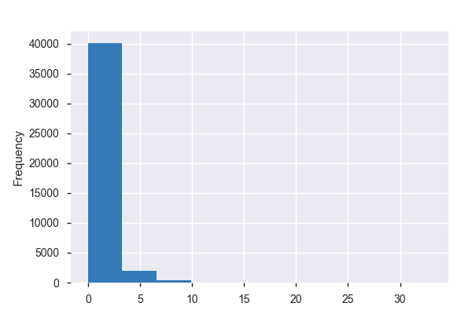

**Common Values**

| Value | Count | Frequency (%) |  |
| --- | --- | --- | --- |
| 0.0 | 19657 | 0.0% |  |
| 1.0 | 11247 | 0.0% |  |
| 2.0 | 5987 | 0.0% |  |
| 3.0 | 3182 | 0.0% |  |
| 4.0 | 1056 | 0.0% |  |
| 5.0 | 596 | 0.0% |  |
| 6.0 | 339 | 0.0% |  |
| 7.0 | 182 | 0.0% |  |
| 8.0 | 115 | 0.0% |  |
| 9.0 | 50 | 0.0% |  |
| Other values (18) | 95 | 0.0% |  |
| (Missing) | 36 | 0.0% |  |

**Extreme Values**

Minimum 5 values

| Value | Count | Frequency (%) |  |
| --- | --- | --- | --- |
| 0.0 | 19657 | 0.0% |  |
| 1.0 | 11247 | 0.0% |  |
| 2.0 | 5987 | 0.0% |  |
| 3.0 | 3182 | 0.0% |  |
| 4.0 | 1056 | 0.0% |  |

Maximum 5 values

| Value | Count | Frequency (%) |  |
| --- | --- | --- | --- |
| 27.0 | 1 | 0.0% |  |
| 28.0 | 1 | 0.0% |  |
| 31.0 | 1 | 0.0% |  |
| 32.0 | 1 | 0.0% |  |
| 33.0 | 1 | 0.0% |  |

int_rate  
Categorical

| Distinct count | 395 |
| --- | --- |
| Unique (%) | 0.0% |
| Missing (%) | 100.0% |
| Missing (n) | 7 |

| 10.99% | 970 |
| --- | --- |
| 11.49% | 837 |
| 13.49% | 832 |
| Other values (391) | 39896 |

Toggle details

| Value | Count | Frequency (%) |  |
| --- | --- | --- | --- |
| 10.99% | 970 | 0.0% |  |
| 11.49% | 837 | 0.0% |  |
| 13.49% | 832 | 0.0% |  |
| 7.51% | 787 | 0.0% |  |
| 7.88% | 742 | 0.0% |  |
| 7.49% | 656 | 0.0% |  |
| 11.71% | 609 | 0.0% |  |
| 9.99% | 607 | 0.0% |  |
| 7.90% | 582 | 0.0% |  |
| 5.42% | 573 | 0.0% |  |
| Other values (384) | 35340 | 0.0% |  |

last_credit_pull_d  
Categorical

| Distinct count | 128 |
| --- | --- |
| Unique (%) | 0.0% |
| Missing (%) | 100.0% |
| Missing (n) | 11 |

| Jan-18 | 9348 |
| --- | --- |
| Oct-16 | 4312 |
| Dec-17 | 905 |
| Other values (124) | 27966 |

Toggle details

| Value | Count | Frequency (%) |  |
| --- | --- | --- | --- |
| Jan-18 | 9348 | 0.0% |  |
| Oct-16 | 4312 | 0.0% |  |
| Dec-17 | 905 | 0.0% |  |
| Nov-17 | 868 | 0.0% |  |
| Oct-17 | 822 | 0.0% |  |
| Feb-17 | 816 | 0.0% |  |
| Sep-17 | 683 | 0.0% |  |
| Aug-17 | 665 | 0.0% |  |
| Feb-13 | 608 | 0.0% |  |
| Mar-16 | 520 | 0.0% |  |
| Other values (117) | 22984 | 0.0% |  |

last_fico_range_high  
Numeric

| Distinct count | 73 |
| --- | --- |
| Unique (%) | 0.0% |
| Missing (%) | 100.0% |
| Missing (n) | 7 |
| Infinite (%) | 0.0% |
| Infinite (n) | 0 |

| Mean | 688.87 |
| --- | --- |
| Minimum | 0 |
| Maximum | 850 |
| Zeros (%) | 0.0% |

Toggle details

**Statistics**

Quantile statistics

| Minimum | 0 |
| --- | --- |
| 5-th percentile | 534 |
| Q1 | 644 |
| Median | 699 |
| Q3 | 744 |
| 95-th percentile | 804 |
| Maximum | 850 |
| Range | 850 |
| Interquartile range | 100 |

Descriptive statistics

| Standard deviation | 80.587 |
| --- | --- |
| Coef of variation | 0.11698 |
| Kurtosis | 2.9593 |
| Mean | 688.87 |
| MAD | 63.353 |
| Skewness | -0.87048 |
| Sum | 29301000 |
| Variance | 6494.2 |
| Memory size | 332.4 KiB |

**Histogram**

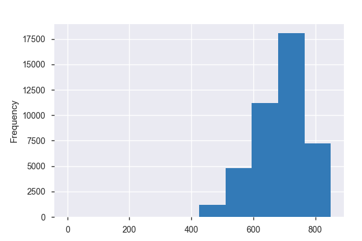

**Common Values**

| Value | Count | Frequency (%) |  |
| --- | --- | --- | --- |
| 709.0 | 1305 | 0.0% |  |
| 694.0 | 1256 | 0.0% |  |
| 699.0 | 1227 | 0.0% |  |
| 724.0 | 1208 | 0.0% |  |
| 719.0 | 1181 | 0.0% |  |
| 714.0 | 1176 | 0.0% |  |
| 704.0 | 1172 | 0.0% |  |
| 684.0 | 1147 | 0.0% |  |
| 689.0 | 1084 | 0.0% |  |
| 734.0 | 1057 | 0.0% |  |
| Other values (62) | 30722 | 0.0% |  |

**Extreme Values**

Minimum 5 values

| Value | Count | Frequency (%) |  |
| --- | --- | --- | --- |
| 0.0 | 28 | 0.0% |  |
| 499.0 | 768 | 0.0% |  |
| 504.0 | 223 | 0.0% |  |
| 509.0 | 177 | 0.0% |  |
| 514.0 | 206 | 0.0% |  |

Maximum 5 values

| Value | Count | Frequency (%) |  |
| --- | --- | --- | --- |
| 829.0 | 177 | 0.0% |  |
| 834.0 | 129 | 0.0% |  |
| 839.0 | 40 | 0.0% |  |
| 844.0 | 34 | 0.0% |  |
| 850.0 | 11 | 0.0% |  |

last_fico_range_low  
Numeric

| Distinct count | 72 |
| --- | --- |
| Unique (%) | 0.0% |
| Missing (%) | 100.0% |
| Missing (n) | 7 |
| Infinite (%) | 0.0% |
| Infinite (n) | 0 |

| Mean | 675.94 |
| --- | --- |
| Minimum | 0 |
| Maximum | 845 |
| Zeros (%) | 0.0% |

Toggle details

**Statistics**

Quantile statistics

| Minimum | 0 |
| --- | --- |
| 5-th percentile | 530 |
| Q1 | 640 |
| Median | 695 |
| Q3 | 740 |
| 95-th percentile | 800 |
| Maximum | 845 |
| Range | 845 |
| Interquartile range | 100 |

Descriptive statistics

| Standard deviation | 119.29 |
| --- | --- |
| Coef of variation | 0.17647 |
| Kurtosis | 16.684 |
| Mean | 675.94 |
| MAD | 73.728 |
| Skewness | -3.3858 |
| Sum | 28751000 |
| Variance | 14229 |
| Memory size | 332.4 KiB |

**Histogram**

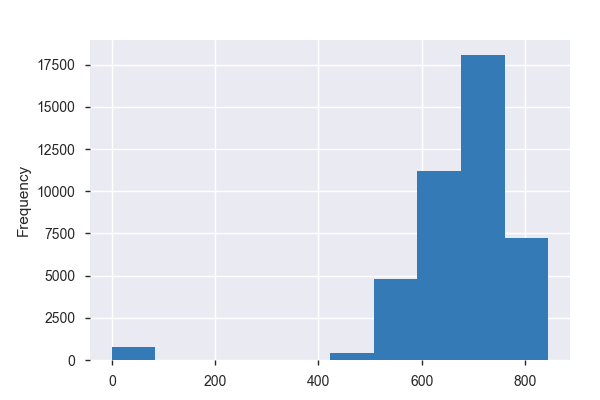

**Common Values**

| Value | Count | Frequency (%) |  |
| --- | --- | --- | --- |
| 705.0 | 1305 | 0.0% |  |
| 690.0 | 1256 | 0.0% |  |
| 695.0 | 1227 | 0.0% |  |
| 720.0 | 1208 | 0.0% |  |
| 715.0 | 1181 | 0.0% |  |
| 710.0 | 1176 | 0.0% |  |
| 700.0 | 1172 | 0.0% |  |
| 680.0 | 1147 | 0.0% |  |
| 685.0 | 1084 | 0.0% |  |
| 730.0 | 1057 | 0.0% |  |
| Other values (61) | 30722 | 0.0% |  |

**Extreme Values**

Minimum 5 values

| Value | Count | Frequency (%) |  |
| --- | --- | --- | --- |
| 0.0 | 796 | 0.0% |  |
| 500.0 | 223 | 0.0% |  |
| 505.0 | 177 | 0.0% |  |
| 510.0 | 206 | 0.0% |  |
| 515.0 | 206 | 0.0% |  |

Maximum 5 values

| Value | Count | Frequency (%) |  |
| --- | --- | --- | --- |
| 825.0 | 177 | 0.0% |  |
| 830.0 | 129 | 0.0% |  |
| 835.0 | 40 | 0.0% |  |
| 840.0 | 34 | 0.0% |  |
| 845.0 | 11 | 0.0% |  |

loan_amnt  
Numeric

| Distinct count | 899 |
| --- | --- |
| Unique (%) | 0.0% |
| Missing (%) | 100.0% |
| Missing (n) | 7 |
| Infinite (%) | 0.0% |
| Infinite (n) | 0 |

| Mean | 11090 |
| --- | --- |
| Minimum | 500 |
| Maximum | 35000 |
| Zeros (%) | 0.0% |

Toggle details

**Statistics**

Quantile statistics

| Minimum | 500 |
| --- | --- |
| 5-th percentile | 2400 |
| Q1 | 5200 |
| Median | 9700 |
| Q3 | 15000 |
| 95-th percentile | 25000 |
| Maximum | 35000 |
| Range | 34500 |
| Interquartile range | 9800 |

Descriptive statistics

| Standard deviation | 7410.9 |
| --- | --- |
| Coef of variation | 0.66827 |
| Kurtosis | 0.78587 |
| Mean | 11090 |
| MAD | 5876.1 |
| Skewness | 1.065 |
| Sum | 471700000 |
| Variance | 54922000 |
| Memory size | 332.4 KiB |

**Histogram**

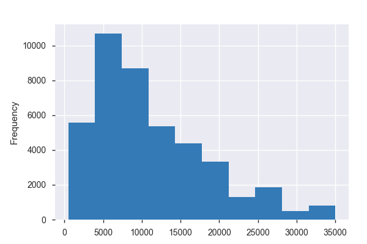

**Common Values**

| Value | Count | Frequency (%) |  |
| --- | --- | --- | --- |
| 10000.0 | 3016 | 0.0% |  |
| 12000.0 | 2439 | 0.0% |  |
| 5000.0 | 2260 | 0.0% |  |
| 6000.0 | 2037 | 0.0% |  |
| 15000.0 | 2012 | 0.0% |  |
| 20000.0 | 1724 | 0.0% |  |
| 8000.0 | 1699 | 0.0% |  |
| 25000.0 | 1499 | 0.0% |  |
| 4000.0 | 1230 | 0.0% |  |
| 3000.0 | 1134 | 0.0% |  |
| Other values (888) | 23485 | 0.0% |  |

**Extreme Values**

Minimum 5 values

| Value | Count | Frequency (%) |  |
| --- | --- | --- | --- |
| 500.0 | 11 | 0.0% |  |
| 550.0 | 1 | 0.0% |  |
| 600.0 | 6 | 0.0% |  |
| 700.0 | 3 | 0.0% |  |
| 725.0 | 1 | 0.0% |  |

Maximum 5 values

| Value | Count | Frequency (%) |  |
| --- | --- | --- | --- |
| 34475.0 | 5 | 0.0% |  |
| 34525.0 | 1 | 0.0% |  |
| 34675.0 | 1 | 0.0% |  |
| 34800.0 | 2 | 0.0% |  |
| 35000.0 | 685 | 0.0% |  |

loan_status  
Categorical

| Distinct count | 5 |
| --- | --- |
| Unique (%) | 0.0% |
| Missing (%) | 100.0% |
| Missing (n) | 7 |

| Fully Paid | 34116 |
| --- | --- |
| Charged Off | 5670 |
| Does not meet the credit policy. Status:Fully Paid | 1988 |

Toggle details

| Value | Count | Frequency (%) |  |
| --- | --- | --- | --- |
| Fully Paid | 34116 | 0.0% |  |
| Charged Off | 5670 | 0.0% |  |
| Does not meet the credit policy. Status:Fully Paid | 1988 | 0.0% |  |
| Does not meet the credit policy. Status:Charged Off | 761 | 0.0% |  |
| (Missing) | 7 | 0.0% |  |

open_acc  
Numeric

| Distinct count | 45 |
| --- | --- |
| Unique (%) | 0.0% |
| Missing (%) | 100.0% |
| Missing (n) | 36 |
| Infinite (%) | 0.0% |
| Infinite (n) | 0 |

| Mean | 9.344 |
| --- | --- |
| Minimum | 1 |
| Maximum | 47 |
| Zeros (%) | 0.0% |

Toggle details

**Statistics**

Quantile statistics

| Minimum | 1 |
| --- | --- |
| 5-th percentile | 3 |
| Q1 | 6 |
| Median | 9 |
| Q3 | 12 |
| 95-th percentile | 18 |
| Maximum | 47 |
| Range | 46 |
| Interquartile range | 6 |

Descriptive statistics

| Standard deviation | 4.4963 |
| --- | --- |
| Coef of variation | 0.4812 |
| Kurtosis | 1.935 |
| Mean | 9.344 |
| MAD | 3.5063 |
| Skewness | 1.042 |
| Sum | 397170 |
| Variance | 20.216 |
| Memory size | 332.4 KiB |

**Histogram**

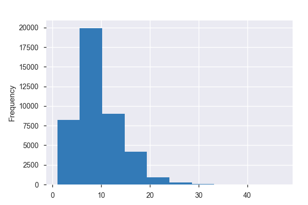

**Common Values**

| Value | Count | Frequency (%) |  |
| --- | --- | --- | --- |
| 7.0 | 4252 | 0.0% |  |
| 8.0 | 4176 | 0.0% |  |
| 6.0 | 4172 | 0.0% |  |
| 9.0 | 3922 | 0.0% |  |
| 10.0 | 3386 | 0.0% |  |
| 5.0 | 3368 | 0.0% |  |
| 11.0 | 2944 | 0.0% |  |
| 4.0 | 2508 | 0.0% |  |
| 12.0 | 2398 | 0.0% |  |
| 13.0 | 2060 | 0.0% |  |
| Other values (34) | 9320 | 0.0% |  |

**Extreme Values**

Minimum 5 values

| Value | Count | Frequency (%) |  |
| --- | --- | --- | --- |
| 1.0 | 39 | 0.0% |  |
| 2.0 | 692 | 0.0% |  |
| 3.0 | 1608 | 0.0% |  |
| 4.0 | 2508 | 0.0% |  |
| 5.0 | 3368 | 0.0% |  |

Maximum 5 values

| Value | Count | Frequency (%) |  |
| --- | --- | --- | --- |
| 41.0 | 1 | 0.0% |  |
| 42.0 | 1 | 0.0% |  |
| 44.0 | 1 | 0.0% |  |
| 46.0 | 1 | 0.0% |  |
| 47.0 | 1 | 0.0% |  |

out_prncp  
Boolean

| Distinct count | 2 |
| --- | --- |
| Unique (%) | 0.0% |
| Missing (%) | 100.0% |
| Missing (n) | 7 |

| Mean | 0 |
| --- | --- |

| 0.0 | 42535 |
| --- | --- |
| (Missing) | 7 |

Toggle details

| Value | Count | Frequency (%) |  |
| --- | --- | --- | --- |
| 0.0 | 42535 | 0.0% |  |
| (Missing) | 7 | 0.0% |  |

out_prncp_inv  
Boolean

| Distinct count | 2 |
| --- | --- |
| Unique (%) | 0.0% |
| Missing (%) | 100.0% |
| Missing (n) | 7 |

| Mean | 0 |
| --- | --- |

| 0.0 | 42535 |
| --- | --- |
| (Missing) | 7 |

Toggle details

| Value | Count | Frequency (%) |  |
| --- | --- | --- | --- |
| 0.0 | 42535 | 0.0% |  |
| (Missing) | 7 | 0.0% |  |

policy_code  
Boolean

| Distinct count | 2 |
| --- | --- |
| Unique (%) | 0.0% |
| Missing (%) | 100.0% |
| Missing (n) | 7 |

| Mean | 1 |
| --- | --- |

| 1.0 | 42535 |
| --- | --- |
| (Missing) | 7 |

Toggle details

| Value | Count | Frequency (%) |  |
| --- | --- | --- | --- |
| 1.0 | 42535 | 0.0% |  |
| (Missing) | 7 | 0.0% |  |

pub_rec  
Numeric

| Distinct count | 7 |
| --- | --- |
| Unique (%) | 0.0% |
| Missing (%) | 100.0% |
| Missing (n) | 36 |
| Infinite (%) | 0.0% |
| Infinite (n) | 0 |

| Mean | 0.058156 |
| --- | --- |
| Minimum | 0 |
| Maximum | 5 |
| Zeros (%) | 0.0% |

Toggle details

**Statistics**

Quantile statistics

| Minimum | 0 |
| --- | --- |
| 5-th percentile | 0 |
| Q1 | 0 |
| Median | 0 |
| Q3 | 0 |
| 95-th percentile | 1 |
| Maximum | 5 |
| Range | 5 |
| Interquartile range | 0 |

Descriptive statistics

| Standard deviation | 0.24571 |
| --- | --- |
| Coef of variation | 4.225 |
| Kurtosis | 26.835 |
| Mean | 0.058156 |
| MAD | 0.10981 |
| Skewness | 4.6055 |
| Sum | 2472 |
| Variance | 0.060375 |
| Memory size | 332.4 KiB |

**Histogram**

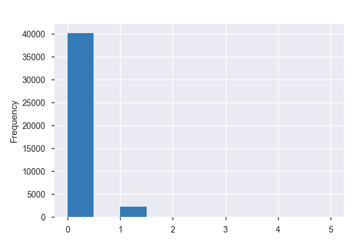

**Common Values**

| Value | Count | Frequency (%) |  |
| --- | --- | --- | --- |
| 0.0 | 40130 | 0.0% |  |
| 1.0 | 2298 | 0.0% |  |
| 2.0 | 64 | 0.0% |  |
| 3.0 | 11 | 0.0% |  |
| 4.0 | 2 | 0.0% |  |
| 5.0 | 1 | 0.0% |  |
| (Missing) | 36 | 0.0% |  |

**Extreme Values**

Minimum 5 values

| Value | Count | Frequency (%) |  |
| --- | --- | --- | --- |
| 0.0 | 40130 | 0.0% |  |
| 1.0 | 2298 | 0.0% |  |
| 2.0 | 64 | 0.0% |  |
| 3.0 | 11 | 0.0% |  |
| 4.0 | 2 | 0.0% |  |

Maximum 5 values

| Value | Count | Frequency (%) |  |
| --- | --- | --- | --- |
| 1.0 | 2298 | 0.0% |  |
| 2.0 | 64 | 0.0% |  |
| 3.0 | 11 | 0.0% |  |
| 4.0 | 2 | 0.0% |  |
| 5.0 | 1 | 0.0% |  |

pub_rec_bankruptcies  
Numeric

| Distinct count | 4 |
| --- | --- |
| Unique (%) | 0.0% |
| Missing (%) | 100.0% |
| Missing (n) | 1372 |
| Infinite (%) | 0.0% |
| Infinite (n) | 0 |

| Mean | 0.045227 |
| --- | --- |
| Minimum | 0 |
| Maximum | 2 |
| Zeros (%) | 0.0% |

Toggle details

**Statistics**

Quantile statistics

| Minimum | 0 |
| --- | --- |
| 5-th percentile | 0 |
| Q1 | 0 |
| Median | 0 |
| Q3 | 0 |
| 95-th percentile | 0 |
| Maximum | 2 |
| Range | 2 |
| Interquartile range | 0 |

Descriptive statistics

| Standard deviation | 0.20874 |
| --- | --- |
| Coef of variation | 4.6153 |
| Kurtosis | 18.127 |
| Mean | 0.045227 |
| MAD | 0.086381 |
| Skewness | 4.4411 |
| Sum | 1862 |
| Variance | 0.043571 |
| Memory size | 332.4 KiB |

**Histogram**

[6 more figures not shown]

Sample

|  | loan_amnt | term | int_rate | grade | sub_grade | emp_title | emp_length | home_ownership | annual_inc | verification_status | loan_status | desc | purpose | title | zip_code | addr_state | dti | delinq_2yrs | earliest_cr_line | fico_range_low | fico_range_high | inq_last_6mths | open_acc | pub_rec | revol_bal | revol_util | total_acc | initial_list_status | out_prncp | … |
| --- | --- | --- | --- | --- | --- | --- | --- | --- | --- | --- | --- | --- | --- | --- | --- | --- | --- | --- | --- | --- | --- | --- | --- | --- | --- | --- | --- | --- | --- | --- |
| 0 | 5000.0 | 36 months | 10.65% | B | B2 | NaN | 10+ years | RENT | 24000.0 | Verified | Fully Paid | Borrower added on 12/22/11 > I need to upgra... | credit_card | Computer | 860xx | AZ | 27.65 | 0.0 | Jan-85 | 735.0 | 739.0 | 1.0 | 3.0 | 0.0 | 13648.0 | 83.70% | 9.0 | f | 0.0 | … |
| 1 | 2500.0 | 60 months | 15.27% | C | C4 | Ryder | < 1 year | RENT | 30000.0 | Source Verified | Charged Off | Borrower added on 12/22/11 > I plan to use t... | car | bike | 309xx | GA | 1.00 | 0.0 | Apr-99 | 740.0 | 744.0 | 5.0 | 3.0 | 0.0 | 1687.0 | 9.40% | 4.0 | f | 0.0 | … |
| 2 | 2400.0 | 36 months | 15.96% | C | C5 | NaN | 10+ years | RENT | 12252.0 | Not Verified | Fully Paid | NaN | small_business | real estate business | 606xx | IL | 8.72 | 0.0 | Nov-01 | 735.0 | 739.0 | 2.0 | 2.0 | 0.0 | 2956.0 | 98.50% | 10.0 | f | 0.0 | … |
| 3 | 10000.0 | 36 months | 13.49% | C | C1 | AIR RESOURCES BOARD | 10+ years | RENT | 49200.0 | Source Verified | Fully Paid | Borrower added on 12/21/11 > to pay for prop... | other | personel | 917xx | CA | 20.00 | 0.0 | Feb-96 | 690.0 | 694.0 | 1.0 | 10.0 | 0.0 | 5598.0 | 21% | 37.0 | f | 0.0 | … |
| 4 | 3000.0 | 60 months | 12.69% | B | B5 | University Medical Group | 1 year | RENT | 80000.0 | Source Verified | Fully Paid | Borrower added on 12/21/11 > I plan on combi... | other | Personal | 972xx | OR | 17.94 | 0.0 | Jan-96 | 695.0 | 699.0 | 0.0 | 15.0 | 0.0 | 27783.0 | 53.90% | 38.0 | f | 0.0 | … |

```python
import pandas as pd
import pandas_profiling
import numpy as np

pandas_profiling.ProfileReport(investor_features)
```

Based on above profiling, lets work on features

*Removals*

```python
unique_loans = investor_features.drop_duplicates()
unique_loans_features = unique_loans.drop(['application_type', 'collections_12_mths_ex_med','fico_range_high',\
                                          'initial_list_status','hardship_flag','out_prncp','out_prncp_inv',\
                                          'policy_code','tax_liens','title','desc','addr_state','earliest_cr_line',\
                                           'emp_title','last_credit_pull_d', 'delinq_amnt', 'last_fico_range_high',\
                                           'zip_code'], axis=1)
unique_loans_features.shape
```

```
(42536, 23)
```

*Converstion*

- revol_util is in % format convert this to numberic
- int_rate feature is in the format 10.99%, convert this to numeric
- replace emp_length '<' symbol in values as XGBoostClassifier wont like it

```python
unique_loans_features['revol_util'] = unique_loans_features['revol_util'].str.replace('%', '').astype(float)
unique_loans_features['int_rate'] = unique_loans_features['int_rate'].str.replace('%', '').astype(float)
#XGB cant have column name with <
unique_loans_features['emp_length'] = unique_loans_features['emp_length'].str.replace('<', '')
```

Consider only if loan_status values is present

```python
unique_loans_features = unique_loans_features[unique_loans_features['loan_status'].notnull()]
```

### Prepare features & targets label

```python
# Split the data into features and target label
loan_paid_status_raw = unique_loans_features['loan_status']
features_raw = unique_loans_features.drop('loan_status', axis = 1)
```

#### Prepare labels

- Lets first work on labels (or target or response variable), which is weather the loan is completely paid of or not.

```python
loans_status_count = unique_loans_features['loan_status'].value_counts().reset_index()
loans_status_count
```

|  | index | loan_status |
| --- | --- | --- |
| 0 | Fully Paid | 34116 |
| 1 | Charged Off | 5670 |
| 2 | Does not meet the credit policy. Status:Fully ... | 1988 |
| 3 | Does not meet the credit policy. Status:Charge... | 761 |

For our project we just need to know weather loans are charged off or not. We will convert the Fully Paid & Does not meet the credit policy. Status:Fully Paid to 0, Charged Off & Does not meet the credit policy. Status:Charged Off to 1

```python
# function to convert target label to numeric values
def convert_label(val):
    #print val
    if val=='Fully Paid':
        return 0
    elif val=='Charged Off':
        return 1
    elif val=='Does not meet the credit policy. Status:Fully Paid':
        return 0
    elif val=='Does not meet the credit policy. Status:Charged Off':
        return 1
```

```python
loan_paid_status = loan_paid_status_raw.apply(convert_label)

loan_paid_status.value_counts().reset_index()
```

|  | index | loan_status |
| --- | --- | --- |
| 0 | 0 | 36104 |
| 1 | 1 | 6431 |

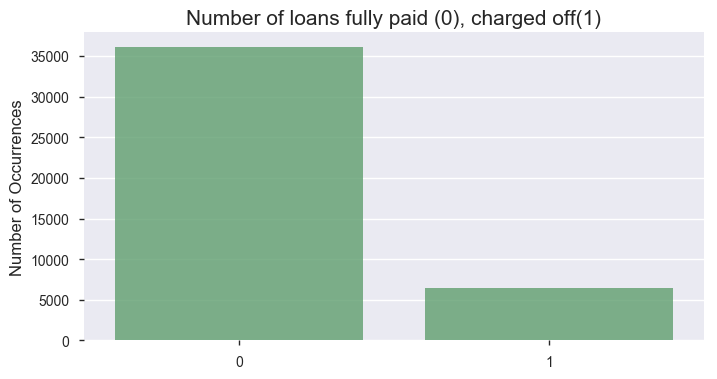

```python
cnt_label = loan_paid_status.value_counts()

plt.figure(figsize=(8,4))
sns.barplot(cnt_label.index, cnt_label.values, alpha=0.8, color=color[1])
plt.ylabel('Number of Occurrences', fontsize=12)
plt.title('Number of loans fully paid (0), charged off(1)', fontsize=15)
plt.show()
```

```python
unique_loans_features['charged_off'] = unique_loans_features['loan_status'].apply(convert_label)
```

```python
pos = unique_loans_features[unique_loans_features["charged_off"] == 1].shape[0]
neg = unique_loans_features[unique_loans_features["charged_off"] == 0].shape[0]
print "Positive examples = {}".format(pos)
print "Negative examples = {}".format(neg)
print "Proportion of positive to negative examples = {}".format((pos*1.0 / neg) * 100)
```

```
Positive examples = 6431
Negative examples = 36104
Proportion of positive to negative examples = 17.8124307556
```

Lets do some basis analysis on data.

Lets validate some of opinions on the loans data

Good fico score based loans shold be paid

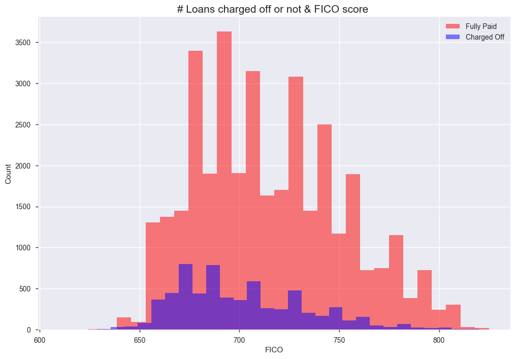

```python
from matplotlib.pyplot import subplots, show

fig, ax = subplots(figsize=(12, 8))
unique_loans_features[unique_loans_features['charged_off'] == 0]['fico_range_low'].hist(alpha=0.5, color='red', bins=30, label='Fully Paid')
unique_loans_features[unique_loans_features['charged_off'] == 1]['fico_range_low'].hist(alpha=0.5, color='blue', bins=30, label='Charged Off')
plt.title("# Loans charged off or not & FICO score ", fontsize=15)
plt.legend()
#plt.xlabel('FICO')
plt.ylabel('Count')
ax.set_xlabel("FICO")
show()
```

- Though loan applicants have good FICO score, 750+, we can see some loans are not paid off
- Highest number of loans paid off are in b/w below 660 to 700 FICO score

What are different purpose the loan is being requested for?

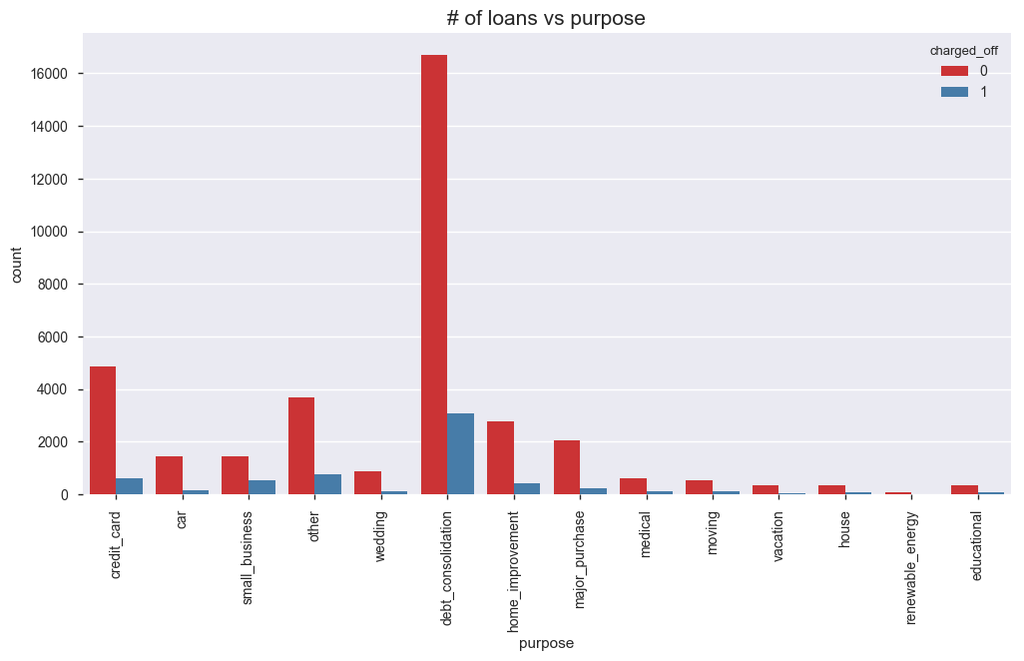

```python
plt.figure(figsize=(12,6))
sns.countplot(x='purpose', data=unique_loans_features, hue='charged_off', palette='Set1')
plt.xticks(rotation='vertical')
plt.title("# of loans vs purpose", fontsize=15)
plt.show()
```

- Most of the loans are being requested for debt_consolidation
- Most charged off loans are also of purpose debt_consolidation

Let's see the trend between FICO score and interest rate.

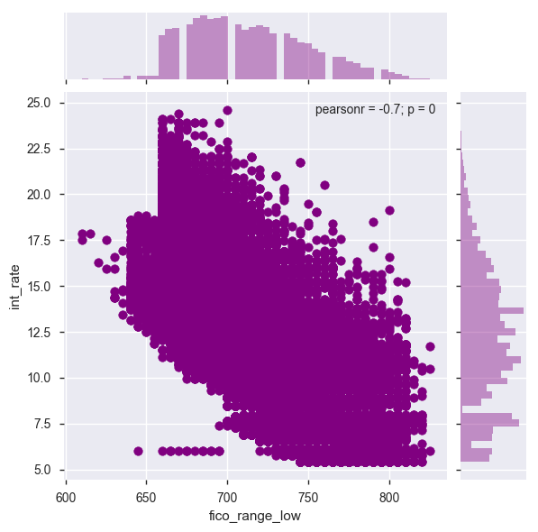

```python
sns.jointplot('fico_range_low', 'int_rate', data=unique_loans_features, color='purple')
```

- Higher the fico score, lower the interest rate

#### Feature selection based on intuition

- Based on above profiling, by spending some time, going through each feature and analyzing each feature, we can first identify the categorical features & numerical features that are populated well to be used for modeling.
- Pandas profiling also profiles the details of highly correlated features using which we don’t need to select some features if they are highly co-related, for example, fico_range_high & fico_range_low, they both are highly co-related so we can use one of them for our analysis and modeling.

```python
categorical_features = ['emp_length', 'grade', 'home_ownership', 'purpose',\
                                     'sub_grade','term','verification_status']
numerical_features = ['acc_now_delinq', 'annual_inc', 'delinq_2yrs', 'int_rate', 'dti', 'fico_range_low'\
                                   ,'inq_last_6mths','last_fico_range_low','loan_amnt'\
                                  ,'open_acc','pub_rec','pub_rec_bankruptcies','revol_bal','revol_util','total_acc']
```

## Missing value

### 1. Handling numerical features missing

Lets identify and treat the missing values

```python
print "Dataset has {} data points with {} numerical variables each.".format(*unique_loans_features[numerical_features].shape)
print(unique_loans_features[numerical_features].isnull().sum())
```

```
Dataset has 42535 data points with 15 numerical variables each.
acc_now_delinq            29
annual_inc                 4
delinq_2yrs               29
int_rate                   0
dti                        0
fico_range_low             0
inq_last_6mths            29
last_fico_range_low        0
loan_amnt                  0
open_acc                  29
pub_rec                   29
pub_rec_bankruptcies    1365
revol_bal                  0
revol_util                90
total_acc                 29
dtype: int64
```

As all above features are sensitive information realted to individual financials, imputing mean, median strategies might not be right, so it is better to impute 0 for NA values than mean, median or mode strategies. Lets impute missing values as 0

```python
unique_loans_features[numerical_features] = unique_loans_features[numerical_features].fillna(0)
```

### 2. Handling categorical features missing

Lets identify and treat the missing categorical feature values

```python
print "Dataset has {} data points with {} numerical variables each.".format(*unique_loans_features[categorical_features].shape)
print(unique_loans_features[categorical_features].isnull().sum())
```

```
Dataset has 42535 data points with 7 numerical variables each.
emp_length             0
grade                  0
home_ownership         0
purpose                0
sub_grade              0
term                   0
verification_status    0
dtype: int64
```

No missing values in categorical features

### Normalizing Numerical Features

Normalization ensures that each feature is treated equally when applying supervised learners.

```python
from sklearn.preprocessing import StandardScaler


# Initialize a scaler, then apply it to the features
scaler = StandardScaler()
features_raw[numerical_features] = scaler.fit_transform(unique_loans_features[numerical_features])

# Show an example of a record with scaling applied
display(features_raw.head(n = 10))

#print(features_raw.isnull().sum())
```

|  | loan_amnt | term | int_rate | grade | sub_grade | emp_length | home_ownership | annual_inc | verification_status | purpose | ... | fico_range_low | inq_last_6mths | open_acc | pub_rec | revol_bal | revol_util | total_acc | last_fico_range_low | acc_now_delinq | pub_rec_bankruptcies |
| --- | --- | --- | --- | --- | --- | --- | --- | --- | --- | --- | --- | --- | --- | --- | --- | --- | --- | --- | --- | --- | --- |
| 0 | -0.821731 | 36 months | -0.408592 | B | B2 | 10+ years | RENT | -0.704100 | Verified | credit_card | ... | 0.606484 | -0.052834 | -1.407944 | -0.236602 | -0.029515 | 1.220348 | -1.129812 | 0.495148 | -0.009698 | -0.213007 |
| 1 | -1.159074 | 60 months | 0.837399 | C | C4 | 1 year | RENT | -0.610491 | Source Verified | car | ... | 0.744651 | 2.566378 | -1.407944 | -0.236602 | -0.572748 | -1.393671 | -1.560731 | -5.666625 | -0.009698 | -0.213007 |
| 2 | -1.172567 | 36 months | 1.023488 | C | C5 | 10+ years | RENT | -0.887387 | Not Verified | small_business | ... | 0.606484 | 0.601969 | -1.630102 | -0.236602 | -0.515113 | 1.741041 | -1.043628 | 0.495148 | -0.009698 | -0.213007 |
| 3 | -0.147044 | 36 months | 0.357342 | C | C1 | 10+ years | RENT | -0.310940 | Source Verified | other | ... | -0.637022 | -0.052834 | 0.147162 | -0.236602 | -0.395122 | -0.985560 | 1.283336 | -0.636606 | -0.009698 | -0.213007 |
| 4 | -1.091605 | 60 months | 0.141586 | B | B5 | 1 year | RENT | 0.169588 | Source Verified | other | ... | -0.498854 | -0.707637 | 1.257952 | -0.236602 | 0.612455 | 0.171926 | 1.369520 | 0.117896 | -0.009698 | -0.213007 |
| 5 | -0.821731 | 36 months | -1.150253 | A | A4 | 3 years | RENT | -0.516881 | Source Verified | wedding | ... | 0.468317 | 1.256772 | -0.074996 | -0.236602 | -0.287710 | -0.728732 | -0.871260 | -0.971941 | -0.009698 | -0.213007 |
| 6 | -0.551856 | 60 months | 1.023488 | C | C5 | 8 years | RENT | -0.345201 | Not Verified | debt_consolidation | ... | -0.637022 | -0.052834 | -0.519312 | -0.236602 | 0.155696 | 1.287194 | -0.957444 | -0.217438 | -0.009698 | -0.213007 |
| 7 | -1.091605 | 36 months | 1.746271 | E | E1 | 9 years | RENT | -0.329662 | Source Verified | car | ... | -1.466025 | 0.601969 | -1.185786 | -0.236602 | -0.275993 | 1.354040 | -1.560731 | 0.075979 | -0.009698 | -0.213007 |
| 8 | -0.740768 | 60 months | 2.458266 | F | F2 | 4 years | OWN | -0.454475 | Source Verified | small_business | ... | -1.051523 | 0.601969 | 0.369320 | -0.236602 | -0.412743 | -0.577449 | -0.785076 | -5.666625 | -0.009698 | -0.213007 |
| 9 | -0.771129 | 60 months | 0.141586 | B | B5 | 1 year | RENT | -0.844514 | Verified | other | ... | 0.330150 | -0.707637 | -1.630102 | -0.236602 | -0.227942 | -0.440240 | -1.646915 | -1.474943 | -0.009698 | -0.213007 |

10 rows × 22 columns

## one-hot encoding categorical features

One-hot encoding creates a "dummy" variable for each possible category of each non-numeric feature.

```python
features= pd.concat([pd.get_dummies(features_raw[categorical_features], prefix_sep='_'),\
                     features_raw[numerical_features]], axis=1)
```

```python
# Print the number of features after one-hot encoding
encoded = list(features.columns)
print "{} total features after one-hot encoding.".format(len(encoded))

print encoded
display(features.head(n = 1))
```

```
93 total features after one-hot encoding.
[u'emp_length_ 1 year', u'emp_length_1 year', u'emp_length_10+ years', u'emp_length_2 years', u'emp_length_3 years', u'emp_length_4 years', u'emp_length_5 years', u'emp_length_6 years', u'emp_length_7 years', u'emp_length_8 years', u'emp_length_9 years', u'emp_length_n/a', u'grade_A', u'grade_B', u'…
```

|  | emp_length_ 1 year | emp_length_1 year | emp_length_10+ years | emp_length_2 years | emp_length_3 years | emp_length_4 years | emp_length_5 years | emp_length_6 years | emp_length_7 years | emp_length_8 years | ... | fico_range_low | inq_last_6mths | last_fico_range_low | loan_amnt | open_acc | pub_rec | pub_rec_bankruptcies | revol_bal | revol_util | total_acc |
| --- | --- | --- | --- | --- | --- | --- | --- | --- | --- | --- | --- | --- | --- | --- | --- | --- | --- | --- | --- | --- | --- |
| 0 | 0 | 0 | 1 | 0 | 0 | 0 | 0 | 0 | 0 | 0 | ... | 0.606484 | -0.052834 | 0.495148 | -0.821731 | -1.407944 | -0.236602 | -0.213007 | -0.029515 | 1.220348 | -1.129812 |

1 rows × 93 columns

## Shuffle and Split Data

Now all categorical variables have been converted into numerical features, and all numerical features have been normalized. As always, we will now split the data (both features and their labels) into training and test sets. 80% of the data will be used for training and 20% for testing.

```python
# Import train_test_split
from sklearn.cross_validation import train_test_split

# Split the 'features' and 'loan_paid_status' data into training and testing sets
X_train, X_test, y_train, y_test = train_test_split(features, loan_paid_status, test_size = 0.2, random_state = 0,\
                                                    stratify= loan_paid_status)

# Show the results of the split
print "Training set has {} samples.".format(X_train.shape[0])
print "Testing set has {} samples.".format(X_test.shape[0])
display(X_test.head(n = 1))
display(y_test.head(n = 1))
```

```
Training set has 34028 samples.
Testing set has 8507 samples.
```

|  | emp_length_ 1 year | emp_length_1 year | emp_length_10+ years | emp_length_2 years | emp_length_3 years | emp_length_4 years | emp_length_5 years | emp_length_6 years | emp_length_7 years | emp_length_8 years | ... | fico_range_low | inq_last_6mths | last_fico_range_low | loan_amnt | open_acc | pub_rec | pub_rec_bankruptcies | revol_bal | revol_util | total_acc |
| --- | --- | --- | --- | --- | --- | --- | --- | --- | --- | --- | --- | --- | --- | --- | --- | --- | --- | --- | --- | --- | --- |
| 20975 | 0 | 0 | 1 | 0 | 0 | 0 | 0 | 0 | 0 | 0 | ... | -0.22252 | -0.052834 | 0.159813 | -0.281981 | -1.407944 | -0.236602 | -0.213007 | -0.294841 | 0.129708 | -0.612709 |

1 rows × 93 columns

```
20975    0
Name: loan_status, dtype: int64
```

## Strategies to deal with imbalanced datasets

Under-Sample: Under-sample the majority class with or w/o replacement by making the number of positive and negative examples equal. One of the drawbacks of under-sampling is that it ignores a good portion of training data that has valuable information. In our example, it would loose around ~27000+ examples. However, it’s very fast to train.

Over-Sample: Over-sample the minority class with or w/o replacement by making the number of positive and negative examples equal. We’ll add around ~27000+ samples from the training data set with this strategy. It’s a lot more computationally expensive than under-sampling. Also, it’s more prune to overfitting due to repeated examples.

EasyEnsemble: Sample several subsets from the majority class, build a classifier on top of each sampled data, and combine the output of all classifiers. More details can be found here.

Synthetic Minority Oversampling Technique (SMOTE): It over-samples the minority class but using synthesized examples. It operates on feature space not the data space.

```python
from sklearn.ensemble import RandomForestClassifier
from sklearn.pipeline import make_pipeline
from sklearn.model_selection import cross_val_score
from imblearn.pipeline import make_pipeline as imb_make_pipeline
from imblearn.under_sampling import RandomUnderSampler
from imblearn.over_sampling import RandomOverSampler
from imblearn.over_sampling import SMOTE
from imblearn.ensemble import BalancedBaggingClassifier

# Build random forest classifier (same config)
rf_clf = RandomForestClassifier(criterion="entropy", verbose=False, class_weight="balanced",random_state=10)
# Build model with no sampling
pip_orig = make_pipeline(rf_clf)
scores = cross_val_score(pip_orig, X_train, y_train, scoring="roc_auc", cv=10)
print("Original model's average AUC: {}".format(scores.mean()))
# Build model with undersampling
pip_undersample = imb_make_pipeline(RandomUnderSampler(), rf_clf)
scores = cross_val_score(pip_undersample, X_train, y_train, scoring="roc_auc", cv=10)
print("Under-sampled model's average AUC: {}".format(scores.mean()))
# Build model with oversampling
pip_oversample = imb_make_pipeline(RandomOverSampler(), rf_clf)
scores = cross_val_score(pip_oversample, X_train, y_train, scoring="roc_auc", cv=10)
print("Over-sampled model's average AUC: {}".format(scores.mean()))
# Build model with EasyEnsemble
resampled_rf = BalancedBaggingClassifier(base_estimator=rf_clf, n_estimators=10, random_state=10)
pip_resampled = make_pipeline(resampled_rf)
scores = cross_val_score(pip_resampled, X_train, y_train, scoring="roc_auc", cv=10)
print("EasyEnsemble model's average AUC: {}".format(scores.mean()))
# Build model with SMOTE
pip_smote = imb_make_pipeline(SMOTE(), rf_clf)
scores = cross_val_score(pip_smote, X_train, y_train, scoring="roc_auc", cv=10)
print("SMOTE model's average AUC: {}".format(scores.mean()))
```

```
Original model's average AUC: 0.825141686061
Under-sampled model's average AUC: 0.841471980485
Over-sampled model's average AUC: 0.840353095013
EasyEnsemble model's average AUC: 0.872006664839
SMOTE model's average AUC: 0.832709723122
```

EasyEnsemble method has the highest 10-folds CV with average AUC = 0.872006664839. So we use EasyEnsemble technique to handle the imbalanced class problem.

## Evaluating Model Performance

### Metrics and the Naive Predictor

*Investor ML*, is particularly interested in predicting who will fully pay back the loan. It would seem that using accuracy as a metric for evaluating a particular model's performace would be appropriate. Additionally, identifying someone that does not fully pay back loan would be detrimental to *Investor ML*, since they are looking to invest on individual who will pay back loan. Therefore, a model's ability to precisely predict those who fully back is more important than the model's ability to recall those individuals. We can use F-beta score as a metric that considers both precision and recall: $$ F_{\beta} = (1 + \beta^2) \cdot \frac{precision \cdot recall}{\left( \beta^2 \cdot precision \right) + recall} $$ In particular, when $\beta = 0.5$, more emphasis is placed on precision. This is called the **F$_{0.5}$** score (or F-score for simplicity). Looking at the distribution of classes (those who charged off, and those who fully pay), it's clear most individuals fully pay back loan. This can greatly affect accuracy, since we could simply say "this person will pay back loan" and generally be right, without ever looking at the data! Making such a statement would be called naive, since we have not considered any information to substantiate the claim. Also as we are trying to predict "Risk Rate%", we cant say loan gets charged off. To define a naive predictor, we will use Gausian NB model to help establish a benchmark for whether a model is performing well.

### Naive Predictor Performace

Lets define naive predictor and check its performance

```python
from sklearn import metrics
from sklearn.metrics import accuracy_score
from sklearn.metrics import precision_score
from sklearn.metrics import recall_score
from sklearn.metrics import fbeta_score
from sklearn.naive_bayes import GaussianNB

cols = ['model','matthews_corrcoef', 'roc_auc_score', 'precision_score', 'recall_score','f1_score','accuracy',\
       'fscore']
models_report = pd.DataFrame(columns = cols)

#The naive model always predict that an individual will fully pay back loan
clf_GNB = GaussianNB()

clf_GNB.fit(X_train,y_train)

naive_prediction = clf_GNB.predict(X_test)
y_score = clf_GNB.predict_proba(X_test)[:,1]

# Accuracy, F-score using sklearn
accuracy = accuracy_score(y_test, naive_prediction)
fscore = fbeta_score(y_test, naive_prediction, beta = 0.5, pos_label=1)

tmp = pd.Series({'model': 'Naive Predictor',\
                 'roc_auc_score' : metrics.roc_auc_score(y_test, y_score),\
                 'matthews_corrcoef': metrics.matthews_corrcoef(y_test, naive_prediction),\
                 'precision_score': metrics.precision_score(y_test, naive_prediction),\
                 'recall_score': metrics.recall_score(y_test, naive_prediction),\
                 'f1_score': metrics.f1_score(y_test, naive_prediction),\
                 'accuracy': accuracy_score(y_test, naive_prediction),\
                 'fscore' : fbeta_score(y_test, naive_prediction, beta = 0.5, pos_label=1)})
models_report = models_report.append(tmp, ignore_index = True)

# Print the results
print "Naive Predictor per sklearn: [Accuracy score: {:.4f}, F-score: {:.4f}]".format(accuracy, fscore)
models_report
```

```
Naive Predictor per sklearn: [Accuracy score: 0.5571, F-score: 0.2567]
```

|  | model | matthews_corrcoef | roc_auc_score | precision_score | recall_score | f1_score | accuracy | fscore |
| --- | --- | --- | --- | --- | --- | --- | --- | --- |
| 0 | Naive Predictor | 0.201287 | 0.696211 | 0.220243 | 0.75972 | 0.341489 | 0.557071 | 0.2567 |

### Creating a Training and Predicting Pipeline

Lets create a training and predicting pipeline that allows you to quickly and effectively train models using various sizes of training data and perform predictions on the testing data.

```python
from sklearn.metrics import fbeta_score, accuracy_score

def train_predict(classifier_name, learner, sample_size, X_train, y_train, X_test, y_test, models_report, meta_learner=None):
    '''
    inputs:
       - learner: the learning algorithm to be trained and predicted on
       - sample_size: the size of samples (number) to be drawn from training set
       - X_train: features training set
       - y_train: income training set
       - X_test: features testing set
       - y_test: income testing set
    '''

    results = {}

    #  Fit the learner to the training data using slicing with 'sample_size'
    start = time() # Get start time
    if meta_learner and classifier_name=='stackedEnsembleClassifier':
        # Use CV to generate meta-features
        meta_features = cross_val_predict(learner, X_train[:sample_size],y_train[:sample_size], cv=10, method="transform")
        # Refit the first stack on the full training set
        learner.fit(X_train[:sample_size],y_train[:sample_size])
        # Fit the meta learner
        second_stack = meta_learner.fit(meta_features, y_train[:sample_size])
    else:
        learner.fit(X_train[:sample_size],y_train[:sample_size])
    end = time() # Get end time

    # Calculate the training time
    results['train_time'] = end-start

    #  Get the predictions on the test set,
    #       then get predictions on the first 300 training samples
    start = time() # Get start time
    if meta_learner and classifier_name=='stackedEnsembleClassifier':
        predictions_test = second_stack.predict(learner.transform(X_test))
        predictions_train = second_stack.predict(learner.transform(X_train[:300]))
    else:
        predictions_test = learner.predict(X_test)
        predictions_train = learner.predict(X_train[:300])

    end = time() # Get end time

    #  Calculate the total prediction time
    results['pred_time'] = end-start

    # Compute accuracy on the first 300 training samples
    results['acc_train'] = accuracy_score(y_train[:300], predictions_train)

    #  Compute accuracy on test set
    results['acc_test'] = accuracy_score(y_test, predictions_test)

    #  Compute F-score on the the first 300 training samples
    results['f_train'] = fbeta_score(y_train[:300], predictions_train, beta = 0.5)

    #  Compute F-score on the test set
    results['f_test'] = fbeta_score(y_test, predictions_test, beta = 0.5)

    if meta_learner and classifier_name=='stackedEnsembleClassifier':
        results['meta-learner'] = second_stack
        results['learner'] = learner
    else:
        results['learner'] = learner
    # Success
    print "{} trained on {} samples.".format(classifier_name, sample_size)

    if classifier_name=='stackedEnsembleClassifier':
        y_score = second_stack.predict_proba(learner.transform(X_test))[:, 1:]
    else:
        y_score = learner.predict_proba(X_test)[:,1]

    tmp = pd.Series({'model': classifier_name+str(sample_size),\
                 'roc_auc_score' : metrics.roc_auc_score(y_test, y_score),\
                 'matthews_corrcoef': metrics.matthews_corrcoef(y_test, predictions_test),\
                 'precision_score': metrics.precision_score(y_test, predictions_test),\
                 'recall_score': metrics.recall_score(y_test, predictions_test),\
                 'f1_score': metrics.f1_score(y_test, predictions_test),\
                 'accuracy': accuracy_score(y_test, predictions_test),\
                 'fscore' : fbeta_score(y_test, predictions_test, beta = 0.5, pos_label=1)})

    models_report = models_report.append(tmp, ignore_index = True)

    # Return the results
    return results, models_report
```

Lets evaluate using following models

- LogisticRegression
- GradientBoostingClassifier
- XGBoostClassifier

```
XGBClassifier trained on 340 samples.
XGBClassifier trained on 3402 samples.
XGBClassifier trained on 34028 samples.
LogisticRegression trained on 340 samples.
LogisticRegression trained on 3402 samples.
LogisticRegression trained on 34028 samples.
GradientBoostingClassifier trained on 340 samples.
GradientBoostingClassifier trained on 3402 samples.
GradientBoostingClassifier trained on 34028 samples.
```

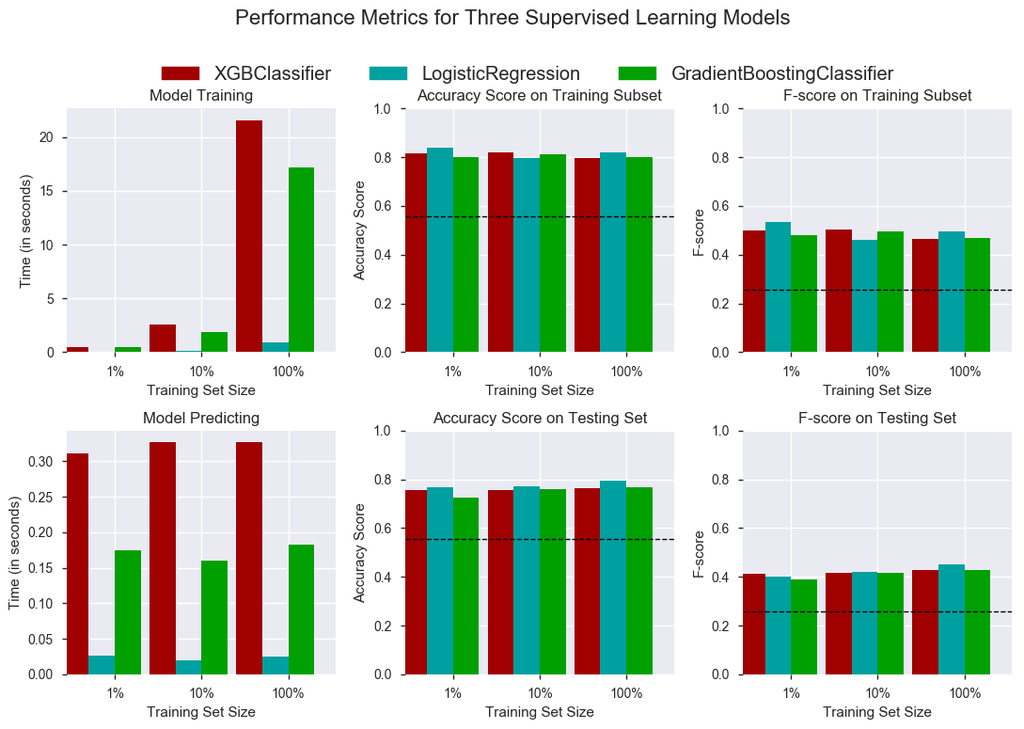

|  | model | matthews_corrcoef | roc_auc_score | precision_score | recall_score | f1_score | accuracy | fscore |
| --- | --- | --- | --- | --- | --- | --- | --- | --- |
| 0 | Naive Predictor | 0.201287 | 0.696211 | 0.220243 | 0.759720 | 0.341489 | 0.557071 | 0.256700 |
| 1 | XGBClassifier340 | 0.441011 | 0.858439 | 0.367037 | 0.846812 | 0.512109 | 0.756083 | 0.413943 |
| 2 | XGBClassifier3402 | 0.450757 | 0.874160 | 0.370445 | 0.861586 | 0.518120 | 0.757729 | 0.418113 |
| 3 | XGBClassifier34028 | 0.462447 | 0.884929 | 0.379299 | 0.866252 | 0.527587 | 0.765487 | 0.427344 |
| 4 | LogisticRegression340 | 0.376855 | 0.824225 | 0.360721 | 0.699844 | 0.476065 | 0.767133 | 0.399432 |
| 5 | LogisticRegression3402 | 0.420559 | 0.848994 | 0.376618 | 0.769051 | 0.505624 | 0.772658 | 0.419423 |
| 6 | LogisticRegression34028 | 0.459866 | 0.870452 | 0.405653 | 0.792379 | 0.536598 | 0.793112 | 0.449532 |
| 7 | GradientBoostingClassifier340 | 0.418919 | 0.843553 | 0.340653 | 0.868585 | 0.489376 | 0.725990 | 0.387793 |
| 8 | GradientBoostingClassifier3402 | 0.446944 | 0.871031 | 0.370395 | 0.852255 | 0.516372 | 0.758669 | 0.417619 |
| 9 | GradientBoostingClassifier34028 | 0.464679 | 0.884464 | 0.380757 | 0.867807 | 0.529286 | 0.766663 | 0.428901 |

```python
from sklearn.ensemble import RandomForestClassifier, GradientBoostingClassifier
from xgboost import XGBClassifier
from sklearn.linear_model import LogisticRegression

# Initialize the four models
clf_A = LogisticRegression(random_state=10)
# Build model with EasyEnsemble
resampled_LR_A = BalancedBaggingClassifier(base_estimator=clf_A, n_estimators=10, random_state=10)
clf_B = GradientBoostingClassifier(random_state=10)
resampled_GBC_B = BalancedBaggingClassifier(base_estimator=clf_B, n_estimators=10, random_state=10)
clf_C = XGBClassifier(objective='binary:logistic', random_state=10)
resampled_XGB_C = BalancedBaggingClassifier(base_estimator=clf_C, n_estimators=10, random_state=10)


# Calculate the number of samples for 1%, 10%, and 100% of the training data
samples_1 = (X_train.shape[0]*1/100)
samples_10 = (X_train.shape[0]*10/100)
samples_100 = (X_train.shape[0]*100/100)

# Collect results on the learners
classifiers = {'LogisticRegression':resampled_LR_A, 'GradientBoostingClassifier':resampled_GBC_B,\
              'XGBClassifier':resampled_XGB_C}
#[resampled_LR_A, resampled_GBC_B, resampled_XGB_C, resampled_RFC_D]
results = {}
for clf_name, clf in classifiers.items():
    #clf_name = clf.__class__.__name__
    results[clf_name] = {}
    for i, samples in enumerate([samples_1, samples_10, samples_100]):
        results[clf_name][i], models_report = \
        train_predict(clf_name, clf, samples, X_train, y_train, X_test, y_test, models_report)

# Run metrics visualization for the three supervised learning models chosen
vs.evaluate(results, accuracy, fscore)
models_report
```

We can see from the above charts and data that, EasySampling, LogisticRegression performs better than, XGBoostClassifier & GradientBoostingClassifier. Considering running time, 100% training size data, variance (train / test of accuracy score is close), F-score.

### Improving Results

Lets perform a grid search optimization for the model over the entire training set (X_train and y_train)

```python
from sklearn.model_selection import GridSearchCV
from sklearn.metrics import make_scorer

# Initialize the classifier
clf = LogisticRegression(random_state=10)
tune_clf = BalancedBaggingClassifier(base_estimator=clf, random_state=10)

# Create the parameters list to tune
parameters = {'base_estimator__fit_intercept': [True],\
              'base_estimator__C': [1.5],\
              'base_estimator__penalty':['l1'],\
              'n_estimators':[10]}


# Make an fbeta_score scoring object
scorer = make_scorer(fbeta_score, beta=0.5)

# Perform grid search on the classifier using 'scorer' as the scoring method
grid_obj = GridSearchCV(tune_clf, parameters, verbose=True, cv=10, scoring=scorer)

#  Fit the grid search object to the training data and find the optimal parameters
grid_fit = grid_obj.fit(X_train, y_train)

# Get the estimator
best_clf = grid_fit.best_estimator_

# Build model with EasyEnsemble
#best_clf= BalancedBaggingClassifier(base_estimator=best_model, n_estimators=10, random_state=10)

# Make predictions using the unoptimized and model
predictions = (tune_clf.fit(X_train, y_train)).predict(X_test)
best_predictions = best_clf.predict(X_test)
```

```
Fitting 10 folds for each of 1 candidates, totalling 10 fits
```

```
[Parallel(n_jobs=1)]: Done  10 out of  10 | elapsed:   20.2s finished
```

```python
y_best_score = best_clf.predict_proba(X_test)[:,1]
tmp = pd.Series({'model': 'GridSearchTunedLR',\
                 'roc_auc_score' : metrics.roc_auc_score(y_test, y_best_score),\
                 'matthews_corrcoef': metrics.matthews_corrcoef(y_test, best_predictions),\
                 'precision_score': metrics.precision_score(y_test, best_predictions),\
                 'recall_score': metrics.recall_score(y_test, best_predictions),\
                 'f1_score': metrics.f1_score(y_test, best_predictions),\
                 'accuracy': accuracy_score(y_test, best_predictions),\
                 'fscore' : fbeta_score(y_test, best_predictions, beta = 0.5, pos_label=1)})

models_report = models_report.append(tmp, ignore_index = True)

# Report the before-and-afterscores
print "Unoptimized model\n------"
print "Accuracy score on testing data: {:.4f}".format(accuracy_score(y_test, predictions))
print "F-score on testing data: {:.4f}".format(fbeta_score(y_test, predictions, beta = 0.5))
print "\nOptimized Model\n------"
print "Final accuracy score on the testing data: {:.4f}".format(accuracy_score(y_test, best_predictions))
print "Final F-score on the testing data: {:.4f}".format(fbeta_score(y_test, best_predictions, beta = 0.5))

# show best parameters
print "\nBest Classifier\n------"
print best_clf
models_report
```

```
Unoptimized model
------
Accuracy score on testing data: 0.7931
F-score on testing data: 0.4495

Optimized Model
------
Final accuracy score on the testing data: 0.7936
Final F-score on the testing data: 0.4507

Best Classifier
------
BalancedBaggingClassifier(base_estimator=LogisticRegression(C=1.5, class_weight=None, dual=False, fit_intercept=True,
          intercept_scaling=1, max_iter=100, multi_class='ovr', n_jobs=1,
          penalty='l1', random_state=10, solver='liblinear', tol=0.0001,
          verbose=0, warm_start=False),
             bootstrap=True, bootstrap_features=False, max_features=1.0,
             max_samples=1.0, n_estimators=10, n_jobs=1, oob_score=False,
             random_state=10, ratio='auto', replacement=False, verbose=0,
             warm_start=False)
```

|  | model | matthews_corrcoef | roc_auc_score | precision_score | recall_score | f1_score | accuracy | fscore |
| --- | --- | --- | --- | --- | --- | --- | --- | --- |
| 0 | Naive Predictor | 0.201287 | 0.696211 | 0.220243 | 0.759720 | 0.341489 | 0.557071 | 0.256700 |
| 1 | XGBClassifier340 | 0.441011 | 0.858439 | 0.367037 | 0.846812 | 0.512109 | 0.756083 | 0.413943 |
| 2 | XGBClassifier3402 | 0.450757 | 0.874160 | 0.370445 | 0.861586 | 0.518120 | 0.757729 | 0.418113 |
| 3 | XGBClassifier34028 | 0.462447 | 0.884929 | 0.379299 | 0.866252 | 0.527587 | 0.765487 | 0.427344 |
| 4 | LogisticRegression340 | 0.376855 | 0.824225 | 0.360721 | 0.699844 | 0.476065 | 0.767133 | 0.399432 |
| 5 | LogisticRegression3402 | 0.420559 | 0.848994 | 0.376618 | 0.769051 | 0.505624 | 0.772658 | 0.419423 |
| 6 | LogisticRegression34028 | 0.459866 | 0.870452 | 0.405653 | 0.792379 | 0.536598 | 0.793112 | 0.449532 |
| 7 | GradientBoostingClassifier340 | 0.418919 | 0.843553 | 0.340653 | 0.868585 | 0.489376 | 0.725990 | 0.387793 |
| 8 | GradientBoostingClassifier3402 | 0.446944 | 0.871031 | 0.370395 | 0.852255 | 0.516372 | 0.758669 | 0.417619 |
| 9 | GradientBoostingClassifier34028 | 0.464679 | 0.884464 | 0.380757 | 0.867807 | 0.529286 | 0.766663 | 0.428901 |
| 10 | GridSearchTunedLR | 0.462095 | 0.870490 | 0.406598 | 0.795490 | 0.538138 | 0.793582 | 0.450661 |

### Feature Importance

An important task when performing supervised learning on a dataset is determining which features provide the most predictive power. By focusing on the relationship between only a few crucial features and the target label we simplify our understanding of the phenomenon, which is most always a useful thing to do. In the case of this project, that means we wish to identify a small number of features that most strongly predict whether an individual fully pay loan.

### Feature Selection

How does a model perform if we only use a subset of all the available features in the data? With less features required to train, the expectation is that training and prediction time is much lower — at the cost of performance metrics.

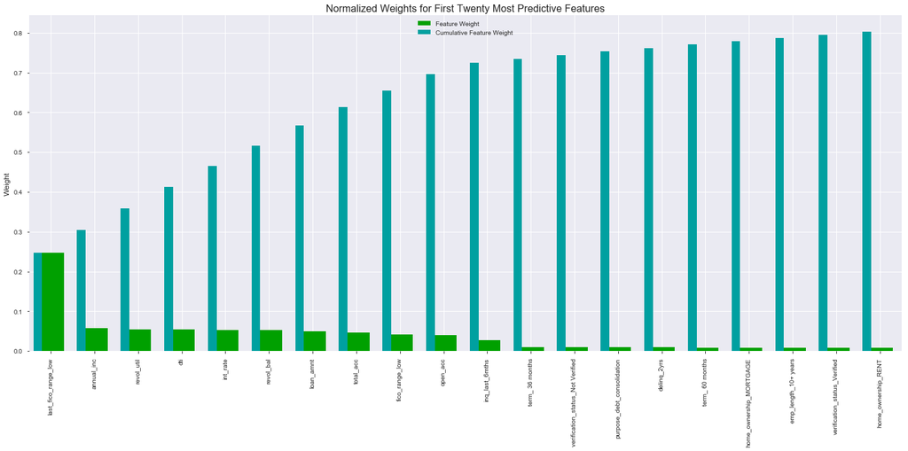

```
 top 20 important features
```

|  | importances | features |
| --- | --- | --- |
| 85 | 0.246455 | last_fico_range_low |
| 79 | 0.0572329 | annual_inc |
| 91 | 0.0544118 | revol_util |
| 82 | 0.0542158 | dti |
| 81 | 0.0523224 | int_rate |
| 90 | 0.0520493 | revol_bal |
| 86 | 0.0496855 | loan_amnt |
| 92 | 0.0466982 | total_acc |
| 83 | 0.042266 | fico_range_low |
| 87 | 0.0408149 | open_acc |
| 84 | 0.0281177 | inq_last_6mths |
| 73 | 0.00973854 | term_ 36 months |
| 75 | 0.0094579 | verification_status_Not Verified |
| 26 | 0.00941782 | purpose_debt_consolidation |
| 80 | 0.00903726 | delinq_2yrs |
| 74 | 0.00870967 | term_ 60 months |
| 19 | 0.00869922 | home_ownership_MORTGAGE |
| 2 | 0.00810152 | emp_length_10+ years |
| 77 | 0.00795508 | verification_status_Verified |
| 23 | 0.00786212 | home_ownership_RENT |

```python
# Import supplementary visualization code visuals.py
import visuals as vs
import matplotlib.pyplot as pl
# Pretty display for notebooks
%matplotlib inline



from sklearn.ensemble import RandomForestClassifier
#  Train the supervised model on the training set
model = RandomForestClassifier(random_state=10)
model.fit(X_train, y_train)
#  Extract the feature importances
importances = model.feature_importances_

# Plot
vs.feature_plot( importances, X_train, y_train)

# show most importance features
a = np.array(importances)
factors = pd.DataFrame(data = np.array([importances.astype(float), features.columns]).T,
                       columns = ['importances', 'features'])
factors = factors.sort_values('importances', ascending=False)

print "\n top 20 important features"
display(factors[:20])
```

```python
# Import functionality for cloning a model
from sklearn.base import clone

# Reduce the feature space
X_train_reduced_20 = X_train[X_train.columns.values[(np.argsort(importances)[::-1])[:20]]]
X_test_reduced_20 = X_test[X_test.columns.values[(np.argsort(importances)[::-1])[:20]]]

# Train on the "best" model found from grid search earlier
start = time()
full_clf = (clone(best_clf)).fit(X_train, y_train)
end = time()
train_time_full = end - start

start = time()
reduced_20_clf = (clone(best_clf)).fit(X_train_reduced_20, y_train)
end = time()
train_time_reduced_20 = end - start


# Make new predictions
full_predictions = full_clf.predict(X_test)
reduced_20_predictions = reduced_20_clf.predict(X_test_reduced_20)

# Report scores from the final model using both versions of data
print "Final Model trained on full data\n------"
print "Final Model Train time {} s full data\n------".format(train_time_full)
print "Accuracy on testing data: {:.4f}".format(accuracy_score(y_test, full_predictions))
print "F-score on testing data: {:.4f}".format(fbeta_score(y_test, full_predictions, beta = 0.5))
print "\nFinal Model trained on reduced to 81 features data\n------"
print "Final Model Train time {} s full data\n------".format(train_time_reduced_20)
print "Accuracy on testing data: {:.4f}".format(accuracy_score(y_test, reduced_20_predictions))
print "F-score on testing data: {:.4f}".format(fbeta_score(y_test, reduced_20_predictions, beta = 0.5))
```

```
Final Model trained on full data
------
Final Model Train time 2.2059469223 s full data
------
Accuracy on testing data: 0.7936
F-score on testing data: 0.4507

Final Model trained on reduced to 81 features data
------
Final Model Train time 1.24439692497 s full data
------
Accuracy on testing data: 0.7932
F-score on testing data: 0.4489
```

Feature selection of using top 20 features wasn’t prudent in our case, so we will use the tuned best classifier with full dataset instead of top 20 feature

### Model Ensemble

We’ll build ensemble models using four different models as base learners:

- LogisticRegression
- GradientBoostingClassifier
- XGBoostClassifier
- RandomForestClassifier

The ensemble models will be built using two different methods:

Blending (average) ensemble model: Fits the base learners to the training data and then, at test time, average the predictions generated by all the base learners. Use VotingClassifier from sklearn that: Fits all the base learners on the training data at test time, use all base learners to predict test data and then take the average of all predictions.

Stacked ensemble model: Fits the base learners to the training data. Next, use those trained base learners to generate predictions (meta-features) used by the meta-learner (assuming we have only one layer of base learners).

There are few different ways of training stacked ensemble model:

Fitting the base learners to all training data and then generate predictions using the same training data it was used to fit those learners. This method is more prune to overfitting because the meta learner will give more weights to the base learner who memorized the training data better, i.e. meta-learner won’t generate well and would overfit.

Split the training data into 2 to 3 different parts that will be used for training, validation, and generate predictions. It’s a suboptimal method because held out sets usually have higher variance and different splits give different results as well as learning algorithms would have fewer data to train.

Use k-folds cross validation where we split the data into k-folds. We fit the base learners to the (k -1) folds and use the fitted models to generate predictions of the held out fold. We repeat the process until we generate the predictions for all the k-folds. When done, refit the base learners to the full training data. This method is more reliable and will give models that memorize the data less weight. Therefore, it generalizes better on future data.

We’ll use logistic regression as the meta-learner for the stacked model. Note that we can use k-folds cross validation to validate and tune the hyperparameters of the meta learner. We will not tune the hyperparameters of any of the base learners or the meta-learner; however, we will use some of the values recommended by the [Data-driven advice for applying machine learning to bioinformatics problems](https://arxiv.org/pdf/1708.05070.pdf) and https://www.analyticsvidhya.com/blog/2016/03/complete-guide-parameter-tuning-xgboost-with-codes-python/.

```python
from sklearn.ensemble import VotingClassifier
# Define base learners
xgb_clf = XGBClassifier(objective="binary:logistic", learning_rate=0.03, n_estimators=500,\
                            max_depth=1, subsample=0.4, random_state=10)

balanced_xgb_clf = BalancedBaggingClassifier(base_estimator=xgb_clf, n_estimators=10, random_state=10)

lr_clf = LogisticRegression(C=1.5, fit_intercept=True, penalty='l1', random_state=10)

balanced_lr_clf = BalancedBaggingClassifier(base_estimator=lr_clf, n_estimators=10, random_state=10)

gb_clf = GradientBoostingClassifier(loss='deviance', learning_rate=0.1, max_depth=3, max_features='log2', \
                                    n_estimators=500, random_state=10)

balanced_gb_clf = BalancedBaggingClassifier(base_estimator=gb_clf, n_estimators=10, random_state=10)

rf_clf = RandomForestClassifier(n_estimators=300, max_features="sqrt", criterion="gini", min_samples_leaf=5,\
                                class_weight="balanced", random_state=10)

balanced_rf_clf = BalancedBaggingClassifier(base_estimator=rf_clf, n_estimators=10, random_state=10)

# Define meta-learner
logreg_clf = LogisticRegression(penalty="l2", C=100, fit_intercept=True)

# Fitting voting clf --> average ensemble
voting_clf = VotingClassifier([("xgb", balanced_xgb_clf), ("lr", balanced_lr_clf), ("gbc", gb_clf),\
                               ("rf", rf_clf)], voting="soft", flatten_transform=True)
voting_clf.fit(X_train, y_train)

xgb_model, lr_model, gbc_model, rf_model = voting_clf.estimators_

models = {"xgb": xgb_model, "lr": lr_model, "gbc": gbc_model, "rf": rf_model, "avg_ensemble": voting_clf}
```

```python
from sklearn.model_selection import cross_val_predict
# Build first stack of base learners
first_stack = make_pipeline(voting_clf)

# Use CV to generate meta-features
meta_features = cross_val_predict(first_stack, X_train, y_train, cv=10, method="transform")

# Refit the first stack on the full training set
first_stack.fit(X_train, y_train)

# Fit the meta learner
second_stack = logreg_clf.fit(meta_features, y_train)
```

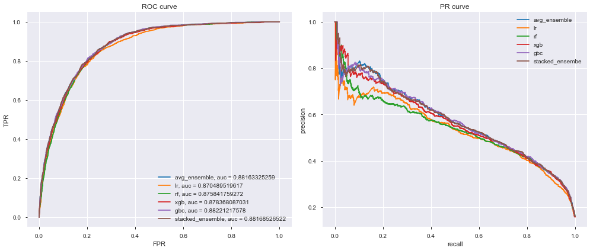

```python
from sklearn.metrics import roc_auc_score
from sklearn.metrics import roc_curve
from sklearn.metrics import precision_recall_curve

# Plot ROC and PR curves using all models and test data
fig, axes = plt.subplots(1, 2, figsize=(14, 6))

for name, model in models.items():
    model_probs = model.predict_proba(X_test)[:, 1:]
    model_auc_score = roc_auc_score(y_test, model_probs)
    fpr, tpr, _ = roc_curve(y_test, model_probs)
    precision, recall, _ = precision_recall_curve(y_test, model_probs)
    axes[0].plot(fpr, tpr, label="{}, auc = {}".format(name, model_auc_score))
    axes[1].plot(recall, precision, label="{}".format(name))

stacked_probs = second_stack.predict_proba(first_stack.transform(X_test))[:, 1:]
stacked_auc_score = roc_auc_score(y_test, stacked_probs)
fpr, tpr, _ = roc_curve(y_test, stacked_probs)
precision, recall, _ = precision_recall_curve(y_test, stacked_probs)
axes[0].plot(fpr, tpr, label="stacked_ensemble, auc = {}".format(stacked_auc_score))
axes[1].plot(recall, precision, label="stacked_ensembe")
axes[0].legend(loc="lower right")
axes[0].set_xlabel("FPR")
axes[0].set_ylabel("TPR")
axes[0].set_title("ROC curve")
axes[1].legend()
axes[1].set_xlabel("recall")
axes[1].set_ylabel("precision")
axes[1].set_title("PR curve")

plt.tight_layout()
```

```python
from sklearn.metrics import f1_score
from sklearn.metrics import confusion_matrix
from sklearn.metrics import classification_report



#PERFORMANCE METRICS FOR TEST SET
print("Final model test METRICS")
y_test_pred = second_stack.predict(first_stack.transform(X_test))

print "Accuracy on testing data: {:.4f}".format(accuracy_score(y_test, y_test_pred))
print "F-score on testing data: {:.4f}".format(fbeta_score(y_test, y_test_pred, beta = 0.5))

accuracy = accuracy_score(y_test, y_test_pred)
print("Accuracy: %.2f%%" % (accuracy * 100.0))

recall = recall_score(y_test, y_test_pred)
print("Recall: %.2f%%" % (recall * 100.0))

precision = precision_score(y_test, y_test_pred)
print("Precision: %.2f%%" % (precision * 100.0))

f1 = f1_score(y_test, y_test_pred, pos_label=1)
print("F1: %.2f%%" % (f1  * 100.0))

cfm = confusion_matrix(y_test, y_test_pred)
print (cfm)

print(classification_report(y_test, y_test_pred))

tmp = pd.Series({'model': 'Stacked Ensemble Final Model',\
                 'roc_auc_score' : stacked_auc_score,\
                 'matthews_corrcoef': metrics.matthews_corrcoef(y_test, y_test_pred),\
                 'precision_score': metrics.precision_score(y_test, y_test_pred),\
                 'recall_score': metrics.recall_score(y_test, y_test_pred),\
                 'f1_score': metrics.f1_score(y_test, y_test_pred),\
                 'accuracy': accuracy_score(y_test, y_test_pred),\
                 'fscore' : fbeta_score(y_test, y_test_pred, beta = 0.5, pos_label=1)})

models_report = models_report.append(tmp, ignore_index = True)
models_report
```

```
Final model test METRICS
Accuracy on testing data: 0.8723
F-score on testing data: 0.5579
Accuracy: 87.23%
Recall: 39.27%
Precision: 62.35%
F1: 48.19%
[[6916  305]
 [ 781  505]]
             precision    recall  f1-score   support

          0       0.90      0.96      0.93      7221
          1       0.62      0.39      0.48      1286

avg / total       0.86      0.87      0.86      8507
```

|  | model | matthews_corrcoef | roc_auc_score | precision_score | recall_score | f1_score | accuracy | fscore |
| --- | --- | --- | --- | --- | --- | --- | --- | --- |
| 0 | Naive Predictor | 0.201287 | 0.696211 | 0.220243 | 0.759720 | 0.341489 | 0.557071 | 0.256700 |
| 1 | XGBClassifier340 | 0.441011 | 0.858439 | 0.367037 | 0.846812 | 0.512109 | 0.756083 | 0.413943 |
| 2 | XGBClassifier3402 | 0.450757 | 0.874160 | 0.370445 | 0.861586 | 0.518120 | 0.757729 | 0.418113 |
| 3 | XGBClassifier34028 | 0.462447 | 0.884929 | 0.379299 | 0.866252 | 0.527587 | 0.765487 | 0.427344 |
| 4 | LogisticRegression340 | 0.376855 | 0.824225 | 0.360721 | 0.699844 | 0.476065 | 0.767133 | 0.399432 |
| 5 | LogisticRegression3402 | 0.420559 | 0.848994 | 0.376618 | 0.769051 | 0.505624 | 0.772658 | 0.419423 |
| 6 | LogisticRegression34028 | 0.459866 | 0.870452 | 0.405653 | 0.792379 | 0.536598 | 0.793112 | 0.449532 |
| 7 | GradientBoostingClassifier340 | 0.418919 | 0.843553 | 0.340653 | 0.868585 | 0.489376 | 0.725990 | 0.387793 |
| 8 | GradientBoostingClassifier3402 | 0.446944 | 0.871031 | 0.370395 | 0.852255 | 0.516372 | 0.758669 | 0.417619 |
| 9 | GradientBoostingClassifier34028 | 0.464679 | 0.884464 | 0.380757 | 0.867807 | 0.529286 | 0.766663 | 0.428901 |
| 10 | GridSearchTunedLR | 0.462095 | 0.870490 | 0.406598 | 0.795490 | 0.538138 | 0.793582 | 0.450661 |
| 11 | Stacked Ensemble Final Model | 0.427706 | 0.881685 | 0.623457 | 0.392691 | 0.481870 | 0.872340 | 0.557888 |

### Final Model Evaluation

Lets check best base classifier, tuned base classifier and final stacked model. Compare thier results for various different set of inputs, to validate robustness and obtain thier outputs. Also plot the ROC curves to perform sensitivity analysis.

```python
bestBaseClassifier = clone(tune_clf)
tunedClassifier = clone(full_clf)
stackedEnsembleClassifier = first_stack
# Define meta-learner
meta_learner = LogisticRegression(penalty="l2", C=100, fit_intercept=True)


# Calculate the number of samples for 1%, 10%, and 100% of the training data
samples_1 = (X_train.shape[0]*1/100)
samples_10 = (X_train.shape[0]*10/100)
samples_100 = (X_train.shape[0]*100/100)

# Collect results on the learners
classifiers2 = {'bestBaseClassifier':bestBaseClassifier, 'tunedClassifier':tunedClassifier,\
              'stackedEnsembleClassifier':stackedEnsembleClassifier}
#[resampled_LR_A, resampled_GBC_B, resampled_XGB_C, resampled_RFC_D]
results2 = {}
for clf_name, clf in classifiers2.items():
    #clf_name = clf.__class__.__name__
    results2[clf_name] = {}
    for i, samples in enumerate([samples_1, samples_10, samples_100]):
        results2[clf_name][i], models_report = \
        train_predict(clf_name, clf, samples, X_train, y_train, X_test, y_test, models_report, meta_learner)
```

```
bestBaseClassifier trained on 340 samples.
bestBaseClassifier trained on 3402 samples.
bestBaseClassifier trained on 34028 samples.
tunedClassifier trained on 340 samples.
tunedClassifier trained on 3402 samples.
tunedClassifier trained on 34028 samples.
stackedEnsembleClassifier trained on 340 samples.
stackedEnsembleClassifier trained on 3402 samples.
stackedEnsembleClassifier trained on 34028 samples.
```

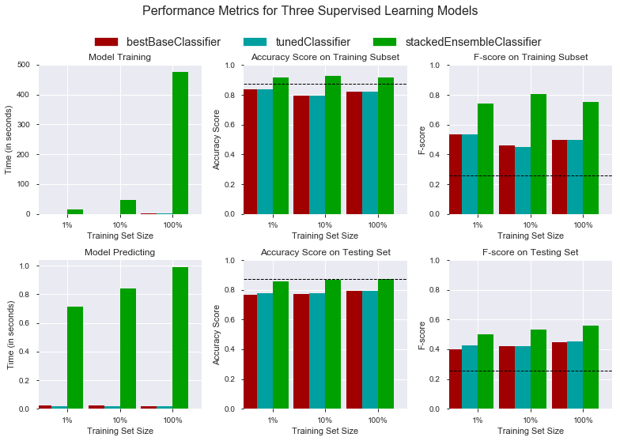

|  | model | matthews_corrcoef | roc_auc_score | precision_score | recall_score | f1_score | accuracy | fscore |
| --- | --- | --- | --- | --- | --- | --- | --- | --- |
| 0 | Naive Predictor | 0.201287 | 0.696211 | 0.220243 | 0.759720 | 0.341489 | 0.557071 | 0.256700 |
| 1 | XGBClassifier340 | 0.441011 | 0.858439 | 0.367037 | 0.846812 | 0.512109 | 0.756083 | 0.413943 |
| 2 | XGBClassifier3402 | 0.450757 | 0.874160 | 0.370445 | 0.861586 | 0.518120 | 0.757729 | 0.418113 |
| 3 | XGBClassifier34028 | 0.462447 | 0.884929 | 0.379299 | 0.866252 | 0.527587 | 0.765487 | 0.427344 |
| 4 | LogisticRegression340 | 0.376855 | 0.824225 | 0.360721 | 0.699844 | 0.476065 | 0.767133 | 0.399432 |
| 5 | LogisticRegression3402 | 0.420559 | 0.848994 | 0.376618 | 0.769051 | 0.505624 | 0.772658 | 0.419423 |
| 6 | LogisticRegression34028 | 0.459866 | 0.870452 | 0.405653 | 0.792379 | 0.536598 | 0.793112 | 0.449532 |
| 7 | GradientBoostingClassifier340 | 0.418919 | 0.843553 | 0.340653 | 0.868585 | 0.489376 | 0.725990 | 0.387793 |
| 8 | GradientBoostingClassifier3402 | 0.446944 | 0.871031 | 0.370395 | 0.852255 | 0.516372 | 0.758669 | 0.417619 |
| 9 | GradientBoostingClassifier34028 | 0.464679 | 0.884464 | 0.380757 | 0.867807 | 0.529286 | 0.766663 | 0.428901 |
| 10 | GridSearchTunedLR | 0.462095 | 0.870490 | 0.406598 | 0.795490 | 0.538138 | 0.793582 | 0.450661 |
| 11 | Stacked Ensemble Final Model | 0.427706 | 0.881685 | 0.623457 | 0.392691 | 0.481870 | 0.872340 | 0.557888 |
| 12 | bestBaseClassifier340 | 0.376855 | 0.824225 | 0.360721 | 0.699844 | 0.476065 | 0.767133 | 0.399432 |
| 13 | bestBaseClassifier3402 | 0.420559 | 0.848994 | 0.376618 | 0.769051 | 0.505624 | 0.772658 | 0.419423 |
| 14 | bestBaseClassifier34028 | 0.459866 | 0.870452 | 0.405653 | 0.792379 | 0.536598 | 0.793112 | 0.449532 |
| 15 | tunedClassifier340 | 0.424741 | 0.852030 | 0.383262 | 0.762053 | 0.510018 | 0.778653 | 0.425569 |
| 16 | tunedClassifier3402 | 0.424213 | 0.852650 | 0.379205 | 0.771384 | 0.508457 | 0.774539 | 0.422128 |
| 17 | tunedClassifier34028 | 0.462095 | 0.870490 | 0.406598 | 0.795490 | 0.538138 | 0.793582 | 0.450661 |
| 18 | stackedEnsembleClassifier340 | 0.377719 | 0.856132 | 0.535752 | 0.390358 | 0.451642 | 0.856706 | 0.498609 |
| 19 | stackedEnsembleClassifier3402 | 0.395049 | 0.873611 | 0.623395 | 0.339813 | 0.439859 | 0.869167 | 0.534230 |
| 20 | stackedEnsembleClassifier34028 | 0.427706 | 0.881685 | 0.623457 | 0.392691 | 0.481870 | 0.872340 | 0.557888 |

```python
# Run metrics visualization for the three supervised learning models chosen
vs.evaluate(results2, accuracy, fscore)
models_report
```

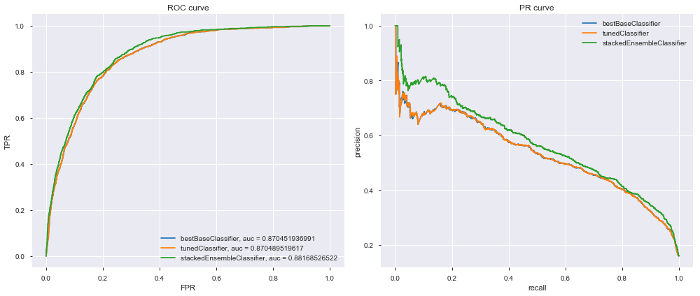

```python
# Plot ROC and PR curves using all models and test data
fig, axes = plt.subplots(1, 2, figsize=(14, 6))
final_first_stack = None
final_second_stack= None

for k, v in results2.items():
    for k2, v2 in v.items():
        if k2==2:
            if k=='stackedEnsembleClassifier':
                final_first_stack = v2['learner']
                final_second_stack = v2['meta-learner']
                stacked_probs = final_second_stack.predict_proba(final_first_stack.transform(X_test))[:, 1:]
                stacked_auc_score = roc_auc_score(y_test, stacked_probs)
                fpr, tpr, _ = roc_curve(y_test, stacked_probs)
                precision, recall, _ = precision_recall_curve(y_test, stacked_probs)
                axes[0].plot(fpr, tpr, label="{}, auc = {}".format(k, stacked_auc_score))
                axes[1].plot(recall, precision, label="{}".format(k))

            else:
                model_probs = v2['learner'].predict_proba(X_test)[:, 1:]
                model_auc_score = roc_auc_score(y_test, model_probs)
                fpr, tpr, _ = roc_curve(y_test, model_probs)
                precision, recall, _ = precision_recall_curve(y_test, model_probs)
                axes[0].plot(fpr, tpr, label="{}, auc = {}".format(k, model_auc_score))
                axes[1].plot(recall, precision, label="{}".format(k))
axes[0].legend(loc="lower right")
axes[0].set_xlabel("FPR")
axes[0].set_ylabel("TPR")
axes[0].set_title("ROC curve")
axes[1].legend()
axes[1].set_xlabel("recall")
axes[1].set_ylabel("precision")
axes[1].set_title("PR curve")
plt.tight_layout()
```

Above ROC plot shows the sensitivity analysis and stackedEnsembleClassifier with AUC 0.88168 is better than bestBaseClassifier and tunedClassifier.

Optimized model's accuracy and F-score on the testing data.

#### Results:

| Metric | Benchmark Predictor | Unoptimized Model | Optimized Model | Stacked Ensemble Final Model |
| --- | --- | --- | --- | --- |
| Accuracy Score | 0.557071 | 0.793112 | 0.793582 | 0.87234 |
| F-score | 0.2567 | 0.449532 | 0.450661 | 0.55788 |

```python
models_report.iloc[[0, 6, 10, 11]].T
```

|  | 0 | 6 | 10 | 11 |
| --- | --- | --- | --- | --- |
| model | Naive Predictor | LogisticRegression34028 | GridSearchTunedLR | Stacked Ensemble Final Model |
| matthews_corrcoef | 0.201287 | 0.459866 | 0.462095 | 0.427706 |
| roc_auc_score | 0.696211 | 0.870452 | 0.87049 | 0.881685 |
| precision_score | 0.220243 | 0.405653 | 0.406598 | 0.623457 |
| recall_score | 0.75972 | 0.792379 | 0.79549 | 0.392691 |
| f1_score | 0.341489 | 0.536598 | 0.538138 | 0.48187 |
| accuracy | 0.557071 | 0.793112 | 0.793582 | 0.87234 |
| fscore | 0.2567 | 0.449532 | 0.450661 | 0.557888 |

- In terms of accuracy, F-score Stacked Ensemble Final Model is much better.
- The Stacked Ensemble Final Model has larger accuracy and F-score compared to Benchmark Naive Predictor, unoptimized model, optimized model.

### Additional visualization

```python
# Plot partial dependence plots
gb_clf = GradientBoostingClassifier(loss='deviance', learning_rate=0.1, max_depth=3, max_features='log2', \
                                    n_estimators=500, random_state=10)

gb_clf.fit(X_train, y_train)
```

```
GradientBoostingClassifier(criterion='friedman_mse', init=None,
              learning_rate=0.1, loss='deviance', max_depth=3,
              max_features='log2', max_leaf_nodes=None,
              min_impurity_decrease=0.0, min_impurity_split=None,
              min_samples_leaf=1, min_samples_split=2,
              min_weight_fraction_leaf=0.0, n_estimators=500,
              presort='auto', random_state=10, subsample=1.0, verbose=0,
              warm_start=False)
```

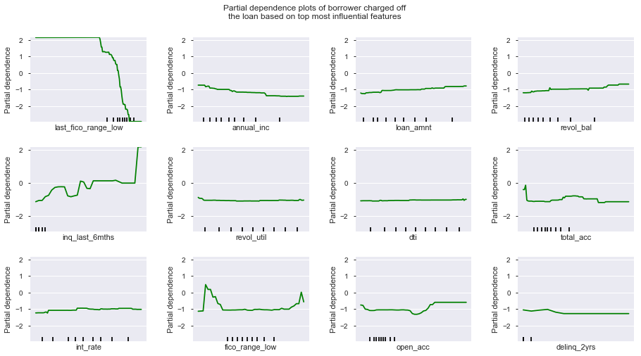

```python
from sklearn.ensemble.partial_dependence import plot_partial_dependence
fig, axes = plot_partial_dependence(gb_clf, X_train, np.argsort(gb_clf.feature_importances_)[::-1][:12],\
                                    n_cols=4, feature_names=features.columns[:], figsize=(14, 8))
plt.subplots_adjust(top=0.9)
plt.suptitle("Partial dependence plots of borrower charged off\n" "the loan based on top most influential features")
for ax in axes:
    ax.set_xticks(())
```

### Final Model

We will trina Stacked Ensemble Final Model with all the data. We will use Stacked Ensemble Final Model to predict whether a loan by individual will be charged off.

```python
# Use CV to generate meta-features
meta_features = cross_val_predict(final_first_stack, features, loan_paid_status, cv=10, method="transform")

# Refit the first stack on the full training set
final_first_stack.fit(features, loan_paid_status)

# Fit the meta learner
final_second_stack_meta = final_second_stack.fit(meta_features, loan_paid_status)
```

### Save the Model

We will save the model using a joblib so that we can use this saved model, infer a new loan will be paid or not based on application data and use *Investor ML* in real time. Final model, we fit using all data available.

```python
from sklearn.externals import joblib
filename = 'finalized_first_stack_model.sav'
filename2 = 'finalized_second_stack_model.sav'

joblib.dump(final_first_stack, filename)
joblib.dump(final_second_stack_meta, filename2)
first_stack
```

```
Pipeline(memory=None,
     steps=[('votingclassifier', VotingClassifier(estimators=[('xgb', BalancedBaggingClassifier(base_estimator=XGBClassifier(base_score=0.5, booster='gbtree', colsample_bylevel=1,
       colsample_bytree=1, gamma=0, learning_rate=0.03, max_delta_step=0,
       max_depth=1, min_child_weight=1, missing=Non...se=0, warm_start=False))],
         flatten_transform=True, n_jobs=1, voting='soft', weights=None))])
```

Test saved model, final model results on par with our best model, performance metric is increased due to increase in data as we used all the data available.

```python
# load the model from disk
loaded_first_stack_model = joblib.load(filename)
loaded_second_stack_model = joblib.load(filename2)
Y_hat_imp_f = loaded_second_stack_model.predict(loaded_first_stack_model.transform(X_test))

print "Accuracy on testing data: {:.4f}".format(accuracy_score(y_test, Y_hat_imp_f))
print "F-score on testing data: {:.4f}".format(fbeta_score(y_test, Y_hat_imp_f, beta = 0.5))
```

```
Accuracy on testing data: 0.8969
F-score on testing data: 0.6729
```

### Conculsion

Most classification problems in the real world are imbalanced. Also, almost always data sets have missing values. In this project, we covered strategies to deal with both missing values and imbalanced data sets. We also explored different ways of building ensembles which can give better performance. Below are some interesting learnings.

- There is no definitive guide of which algorithms to use given any situation. What may work on some data sets may not necessarily work on others. Therefore, always evaluate methods using cross validation to get a reliable estimates.
- Sometimes we may be willing to give up some improvement to the model if that would increase the complexity much more than the percentage change in the improvement to the evaluation metrics.
- EasyEnsemble usually performs better than any other resampling methods.
- Missing values sometimes add more information to the model than we might expect.

#### Improvements

Following are some of the additional improvements that can be done,

- In some classification problems, False Negatives are a lot more expensive than False Positives. Therefore, we can reduce cut-off points to reduce the False Negatives.
- When building ensemble models, try to use good models that are as different as possible to reduce correlation between the base learners. We could’ve enhanced our stacked ensemble model by adding Dense Neural Network and some other kind of base learners as well as adding more layers to the stacked model.
- Add binary features for each feature that has missing values to check if each example is missing or not.